# TP MPDW Pert 5

NIda Khairunnissa

2025-09-19

# Kasus 1 - MA(2)

## Pembangkitan Data

### Manual

```r
set.seed(1061)
n <- 300
wn <- rnorm(n+2)

theta1 <- 0.4
theta2 <- 0.6

ma2_manual <- rep(NA, n)
for(i in 3:302){
   ma2_manual[i-2] <- wn[i] + theta1*wn[i-1] + theta2*wn[i-2]
}
ma2_manual
```

```
##   [1]  0.26769450 -2.88626505 -2.43676294 -2.28131581  0.04979783  1.33925571
##   [7]  0.23138443  0.39808939 -0.67609116  0.31830540  0.24265002 -1.72772200
##  [13] -1.60555190 -1.14153844 -0.61361823  0.25018905  0.97865501  0.38226453
##  [19]  2.65749453  0.45662382  1.84907204  1.46355736  1.18250454  2.28758982
##  [25] -0.08011880  1.38739886 -1.53900503 -0.96452384  0.27173118 -1.31640965
##  [31] -0.28021640 -1.77270601 -0.67481978  0.94447600  0.90102582  0.24202944
##  [37]  0.30926610  0.80006017  0.69839663  2.94687445  1.93686808  1.60217842
##  [43]  1.19468198 -0.66106659 -0.18891591 -0.41319555 -0.46840017 -1.46356464
##  [49] -0.39007762  0.26546056 -0.23113749 -0.07762227 -0.81730710 -1.03849780
##  [55] -1.55372803 -1.49112108  0.30297346  1.10495406 -0.72787447 -0.65678167
##  [61] -2.51955200 -0.52482895 -1.17298937  0.46783023  1.15379901  1.56997342
##  [67]  1.86560381 -1.90949931  0.09421027 -2.01842829  2.03028730 -0.70680325
##  [73]  1.76569228  2.31529166  1.37139143  1.98878093 -2.11159228 -1.02131523
##  [79] -2.38559442  1.21191125 -0.25216118  1.14441919 -1.67616506 -1.92747164
##  [85] -0.76486810 -3.23034915 -0.84349546 -1.82305568 -0.43616944 -0.55477878
```

[output cut: 35 more lines]

### Dengan Fungsi Arima.sim

```r
ma2_asim <- arima.sim(list(order=c(0,0,2), ma=c(0.4, 0.6)), n=300) # 3 parameter p utk ar, d utk i, q utk ma.
ma2_asim
```

```
## Time Series:
## Start = 1
## End = 300
## Frequency = 1
##   [1]  0.763294353  1.063718638 -0.684887496 -1.601074080 -0.830008640
##   [6] -0.061475942  0.059942893  0.629999510  0.455943655  0.981199262
##  [11] -0.383578723  1.299353494  0.691720367  1.212400641  0.427279802
##  [16] -1.427800045 -0.095873492 -1.149723747  0.104118997 -1.363312548
##  [21]  1.613492588 -0.450220027  1.219695883  2.224596769  0.907259977
##  [26]  2.776777428  0.114107789 -0.712501537 -1.005387383  0.272170905
##  [31] -0.206995038  1.204158466  0.855353293 -0.136128945 -1.471874261
##  [36] -3.776029949 -1.615557493 -1.587495463 -0.877474742 -0.976265978
##  [41]  1.181286061  0.518771173  0.868617460 -0.068095779 -1.564497825
##  [46] -2.185247721 -1.309832062 -0.024538917 -0.399117245 -0.029898486
##  [51]  2.729444927  2.232459248  2.086031182 -0.855561214 -0.797571690
```

[output cut: 49 more lines]

## Karakteristik MA(2)

### Plot Time Series

#### WN Manual

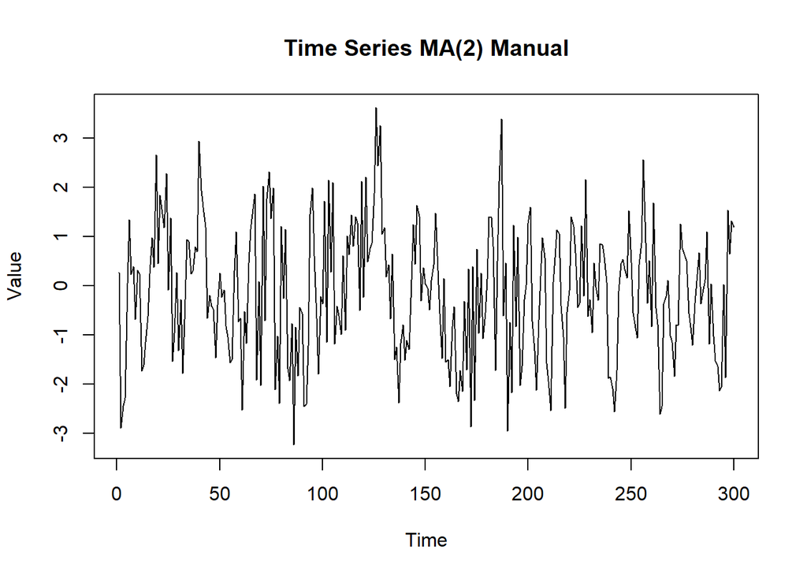

```r
ts.plot(ma2_manual, main = "Time Series MA(2) Manual", ylab = "Value", xlab = "Time")
```

Berdasarkan plot time series, terlihat bahwa data MA(2) yang dibangkitkan manual stasioner dalam rataan karena pola berfluktuasi di sekitar rata-rata nol.

#### WN Arima.sim

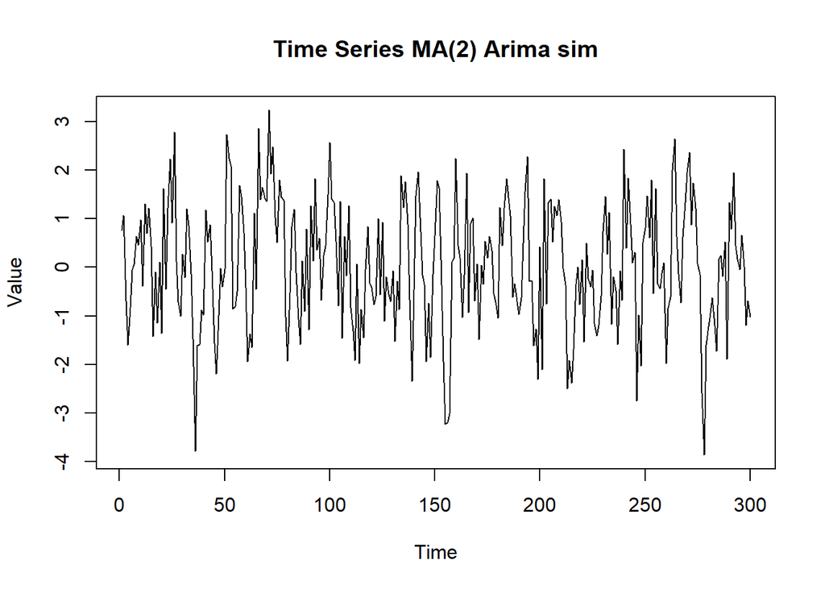

```r
ts.plot(ma2_asim, main = "Time Series MA(2) Arima sim", ylab = "Value", xlab = "Time")
```

Berdasarkan plot time series, terlihat bahwa data MA(2) yang dibangkitkan dengan arima sim stasioner dalam rataan karena pola berfluktuasi di sekitar rata-rata nol.

### Plot ACF

#### WN Manual

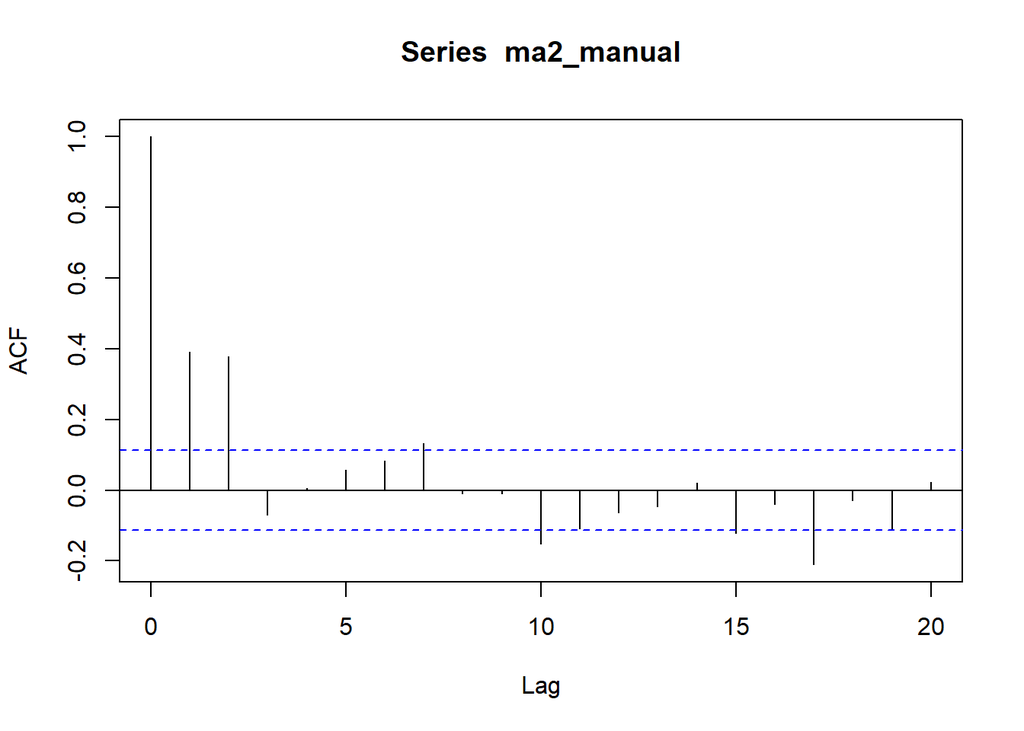

```r
acf_manual <- acf(ma2_manual,lag.max = 20)
```

Berdasarkan plot ACF dari WN manual tersebut, terlihat bahwa plot ACF *cuts off* di lag kedua.

#### WN Arima.sim

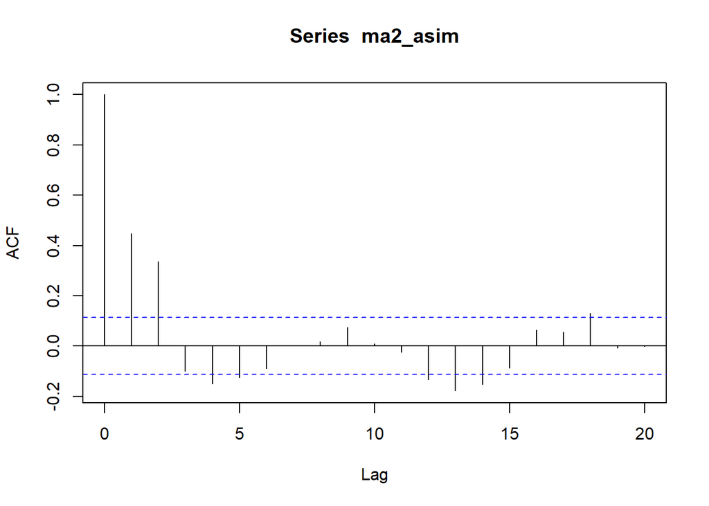

```r
acf_asim <- acf(ma2_asim,lag.max = 20)
```

Berdasarkan plot ACF dari WN dengan Arima.sim tersebut, terlihat bahwa plot ACF *cuts off* di lag kedua.

### Plot PACF

#### WN Manual

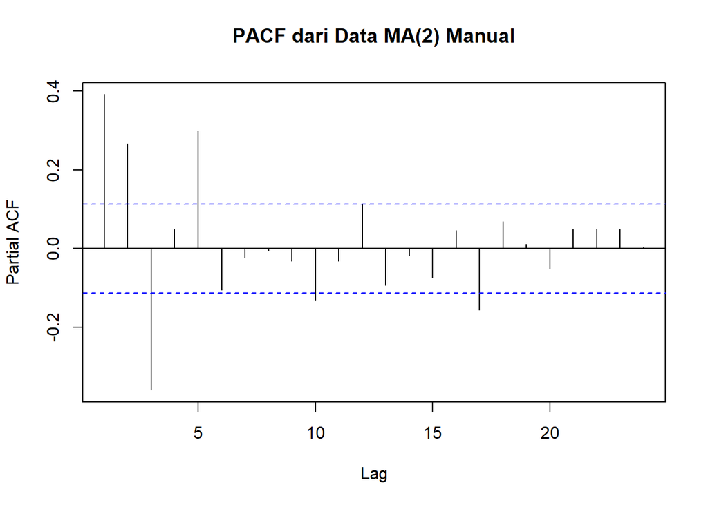

```r
pacf(ma2_manual, main = "PACF dari Data MA(2) Manual")
```

Berdasarkan plot PACF tersebut, terlihat bahwa plot PACF cenderung *tails off* dan membentuk gelombang sinusoidal.

#### WN Arima.sim

[figure not shown]

```r
pacf(ma2_manual, main = "PACF dari Data MA(2) Arima.sim")
```

### Plot EACF

#### WN Manual

```r
TSA::eacf(ma2_manual)
```

```
## AR/MA
##   0 1 2 3 4 5 6 7 8 9 10 11 12 13
## 0 x x o o o o x o o x o  o  o  o
## 1 x x o o o o x o o x o  o  o  o
## 2 x x o x o o x o o x x  o  o  o
## 3 x x x o o o o o o x o  o  o  o
## 4 x x x o x x o o o x o  o  o  o
## 5 x x o x x x o o o o x  o  o  o
## 6 x o o o x x o x o o x  o  o  o
## 7 x o o o x x o x x o x  o  o  o
```

Berdasarkan pola segitiga nol pada plot EACF, terlihat bahwa segitiga nol berada pada ordo AR(0) dan ordo MA(2)

#### WN Arima.sim

```r
TSA::eacf(ma2_asim)
```

```
## AR/MA
##   0 1 2 3 4 5 6 7 8 9 10 11 12 13
## 0 x x o x x o o o o o o  x  x  x
## 1 x x x o o o o o o o o  o  o  o
## 2 x x x o o o o o o o o  o  o  o
## 3 x x x o x o o o o o o  o  o  o
## 4 x x o o x o o o o o o  o  o  o
## 5 x x o o x o o o o o o  o  o  o
## 6 x x o o o o x o o o o  o  o  o
## 7 x x x o o x x o o o o  o  o  o
```

#### Kesimpulan

Berdasarkan plot time series, ACF, dan PACF, data hasil simulasi (baik manual maupun dengan arima.sim) dapat dikatakan stasioner. Tidak terdapat indikasi tren atau perubahan varians, dan pola ACF/PACF sesuai dengan karakteristik proses MA(2).

## Scatterplot Antar Lag

### Korelasi antara $Y_t$ dengan $Y_{t-1}$

#### WN Manual

```r
#Yt
yt_ma <- ma2_manual[-1]
yt_ma
```

```
##   [1] -2.88626505 -2.43676294 -2.28131581  0.04979783  1.33925571  0.23138443
##   [7]  0.39808939 -0.67609116  0.31830540  0.24265002 -1.72772200 -1.60555190
##  [13] -1.14153844 -0.61361823  0.25018905  0.97865501  0.38226453  2.65749453
##  [19]  0.45662382  1.84907204  1.46355736  1.18250454  2.28758982 -0.08011880
##  [25]  1.38739886 -1.53900503 -0.96452384  0.27173118 -1.31640965 -0.28021640
##  [31] -1.77270601 -0.67481978  0.94447600  0.90102582  0.24202944  0.30926610
##  [37]  0.80006017  0.69839663  2.94687445  1.93686808  1.60217842  1.19468198
##  [43] -0.66106659 -0.18891591 -0.41319555 -0.46840017 -1.46356464 -0.39007762
##  [49]  0.26546056 -0.23113749 -0.07762227 -0.81730710 -1.03849780 -1.55372803
##  [55] -1.49112108  0.30297346  1.10495406 -0.72787447 -0.65678167 -2.51955200
##  [61] -0.52482895 -1.17298937  0.46783023  1.15379901  1.56997342  1.86560381
##  [67] -1.90949931  0.09421027 -2.01842829  2.03028730 -0.70680325  1.76569228
##  [73]  2.31529166  1.37139143  1.98878093 -2.11159228 -1.02131523 -2.38559442
##  [79]  1.21191125 -0.25216118  1.14441919 -1.67616506 -1.92747164 -0.76486810
##  [85] -3.23034915 -0.84349546 -1.82305568 -0.43616944 -0.55477878 -2.44952645
```

[output cut: 35 more lines]

```r
#Yt-1
yt_1_ma <- ma2_manual[-300]
yt_1_ma
```

```
##   [1]  0.26769450 -2.88626505 -2.43676294 -2.28131581  0.04979783  1.33925571
##   [7]  0.23138443  0.39808939 -0.67609116  0.31830540  0.24265002 -1.72772200
##  [13] -1.60555190 -1.14153844 -0.61361823  0.25018905  0.97865501  0.38226453
##  [19]  2.65749453  0.45662382  1.84907204  1.46355736  1.18250454  2.28758982
##  [25] -0.08011880  1.38739886 -1.53900503 -0.96452384  0.27173118 -1.31640965
##  [31] -0.28021640 -1.77270601 -0.67481978  0.94447600  0.90102582  0.24202944
##  [37]  0.30926610  0.80006017  0.69839663  2.94687445  1.93686808  1.60217842
##  [43]  1.19468198 -0.66106659 -0.18891591 -0.41319555 -0.46840017 -1.46356464
##  [49] -0.39007762  0.26546056 -0.23113749 -0.07762227 -0.81730710 -1.03849780
##  [55] -1.55372803 -1.49112108  0.30297346  1.10495406 -0.72787447 -0.65678167
##  [61] -2.51955200 -0.52482895 -1.17298937  0.46783023  1.15379901  1.56997342
##  [67]  1.86560381 -1.90949931  0.09421027 -2.01842829  2.03028730 -0.70680325
##  [73]  1.76569228  2.31529166  1.37139143  1.98878093 -2.11159228 -1.02131523
##  [79] -2.38559442  1.21191125 -0.25216118  1.14441919 -1.67616506 -1.92747164
##  [85] -0.76486810 -3.23034915 -0.84349546 -1.82305568 -0.43616944 -0.55477878
```

[output cut: 35 more lines]

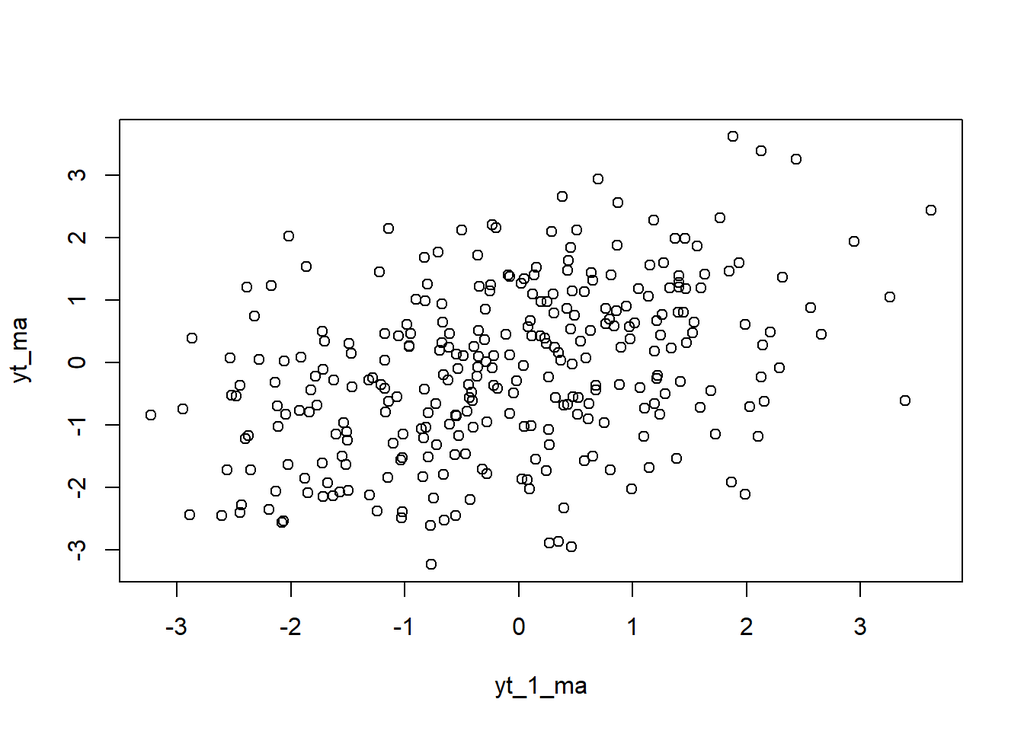

```r
plot(y=yt_ma,x=yt_1_ma)
```

```r
cor(yt_ma,yt_1_ma)
```

```
## [1] 0.3925881
```

#### WN Arima.sim

```r
#Yt
yt_ma <- ma2_asim[-1]
yt_ma
```

```
##   [1]  1.063718638 -0.684887496 -1.601074080 -0.830008640 -0.061475942
##   [6]  0.059942893  0.629999510  0.455943655  0.981199262 -0.383578723
##  [11]  1.299353494  0.691720367  1.212400641  0.427279802 -1.427800045
##  [16] -0.095873492 -1.149723747  0.104118997 -1.363312548  1.613492588
##  [21] -0.450220027  1.219695883  2.224596769  0.907259977  2.776777428
##  [26]  0.114107789 -0.712501537 -1.005387383  0.272170905 -0.206995038
##  [31]  1.204158466  0.855353293 -0.136128945 -1.471874261 -3.776029949
##  [36] -1.615557493 -1.587495463 -0.877474742 -0.976265978  1.181286061
##  [41]  0.518771173  0.868617460 -0.068095779 -1.564497825 -2.185247721
##  [46] -1.309832062 -0.024538917 -0.399117245 -0.029898486  2.729444927
##  [51]  2.232459248  2.086031182 -0.855561214 -0.797571690 -0.504299895
##  [56]  1.685951163  1.455789330  0.715196561 -0.412462897 -1.935383335
##  [61] -1.367063932 -1.646282322  1.115311882 -0.454086727  2.856542760
##  [66]  1.387610751  1.648831050  1.430208314  1.355924982  3.228220785
##  [71]  1.926963263  2.482365237  1.020093686  0.513956475  1.796005999
```

[output cut: 45 more lines]

```r
#Yt-1
yt_1_ma <- ma2_asim[-300]
yt_1_ma
```

```
##   [1]  0.763294353  1.063718638 -0.684887496 -1.601074080 -0.830008640
##   [6] -0.061475942  0.059942893  0.629999510  0.455943655  0.981199262
##  [11] -0.383578723  1.299353494  0.691720367  1.212400641  0.427279802
##  [16] -1.427800045 -0.095873492 -1.149723747  0.104118997 -1.363312548
##  [21]  1.613492588 -0.450220027  1.219695883  2.224596769  0.907259977
##  [26]  2.776777428  0.114107789 -0.712501537 -1.005387383  0.272170905
##  [31] -0.206995038  1.204158466  0.855353293 -0.136128945 -1.471874261
##  [36] -3.776029949 -1.615557493 -1.587495463 -0.877474742 -0.976265978
##  [41]  1.181286061  0.518771173  0.868617460 -0.068095779 -1.564497825
##  [46] -2.185247721 -1.309832062 -0.024538917 -0.399117245 -0.029898486
##  [51]  2.729444927  2.232459248  2.086031182 -0.855561214 -0.797571690
##  [56] -0.504299895  1.685951163  1.455789330  0.715196561 -0.412462897
##  [61] -1.935383335 -1.367063932 -1.646282322  1.115311882 -0.454086727
##  [66]  2.856542760  1.387610751  1.648831050  1.430208314  1.355924982
##  [71]  3.228220785  1.926963263  2.482365237  1.020093686  0.513956475
```

[output cut: 45 more lines]

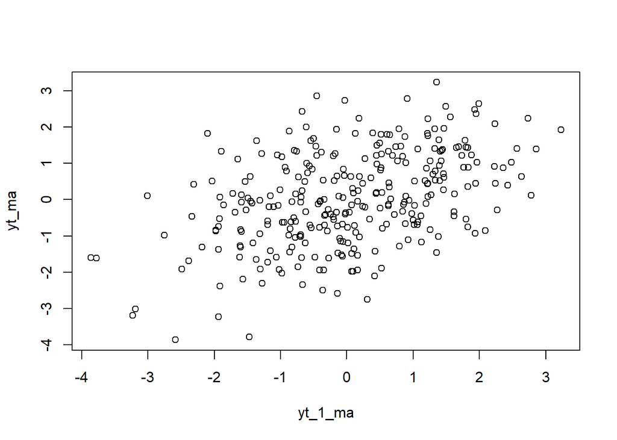

```r
plot(y=yt_ma,x=yt_1_ma)
```

```r
cor(yt_ma,yt_1_ma)
```

```
## [1] 0.4477365
```

### Korelasi antara $Y_t$ dengan $Y_{t-2}$

#### WN Manual

```r
#Yt
yt_ma2 <- ma2_manual[-c(1,2)]
yt_ma2
```

```
##   [1] -2.43676294 -2.28131581  0.04979783  1.33925571  0.23138443  0.39808939
##   [7] -0.67609116  0.31830540  0.24265002 -1.72772200 -1.60555190 -1.14153844
##  [13] -0.61361823  0.25018905  0.97865501  0.38226453  2.65749453  0.45662382
##  [19]  1.84907204  1.46355736  1.18250454  2.28758982 -0.08011880  1.38739886
##  [25] -1.53900503 -0.96452384  0.27173118 -1.31640965 -0.28021640 -1.77270601
##  [31] -0.67481978  0.94447600  0.90102582  0.24202944  0.30926610  0.80006017
##  [37]  0.69839663  2.94687445  1.93686808  1.60217842  1.19468198 -0.66106659
##  [43] -0.18891591 -0.41319555 -0.46840017 -1.46356464 -0.39007762  0.26546056
##  [49] -0.23113749 -0.07762227 -0.81730710 -1.03849780 -1.55372803 -1.49112108
##  [55]  0.30297346  1.10495406 -0.72787447 -0.65678167 -2.51955200 -0.52482895
##  [61] -1.17298937  0.46783023  1.15379901  1.56997342  1.86560381 -1.90949931
##  [67]  0.09421027 -2.01842829  2.03028730 -0.70680325  1.76569228  2.31529166
##  [73]  1.37139143  1.98878093 -2.11159228 -1.02131523 -2.38559442  1.21191125
##  [79] -0.25216118  1.14441919 -1.67616506 -1.92747164 -0.76486810 -3.23034915
##  [85] -0.84349546 -1.82305568 -0.43616944 -0.55477878 -2.44952645 -2.39964816
```

[output cut: 35 more lines]

```r
#Yt-2
yt_2_ma <- ma2_manual[-c(299,300)]
yt_2_ma
```

```
##   [1]  0.26769450 -2.88626505 -2.43676294 -2.28131581  0.04979783  1.33925571
##   [7]  0.23138443  0.39808939 -0.67609116  0.31830540  0.24265002 -1.72772200
##  [13] -1.60555190 -1.14153844 -0.61361823  0.25018905  0.97865501  0.38226453
##  [19]  2.65749453  0.45662382  1.84907204  1.46355736  1.18250454  2.28758982
##  [25] -0.08011880  1.38739886 -1.53900503 -0.96452384  0.27173118 -1.31640965
##  [31] -0.28021640 -1.77270601 -0.67481978  0.94447600  0.90102582  0.24202944
##  [37]  0.30926610  0.80006017  0.69839663  2.94687445  1.93686808  1.60217842
##  [43]  1.19468198 -0.66106659 -0.18891591 -0.41319555 -0.46840017 -1.46356464
##  [49] -0.39007762  0.26546056 -0.23113749 -0.07762227 -0.81730710 -1.03849780
##  [55] -1.55372803 -1.49112108  0.30297346  1.10495406 -0.72787447 -0.65678167
##  [61] -2.51955200 -0.52482895 -1.17298937  0.46783023  1.15379901  1.56997342
##  [67]  1.86560381 -1.90949931  0.09421027 -2.01842829  2.03028730 -0.70680325
##  [73]  1.76569228  2.31529166  1.37139143  1.98878093 -2.11159228 -1.02131523
##  [79] -2.38559442  1.21191125 -0.25216118  1.14441919 -1.67616506 -1.92747164
##  [85] -0.76486810 -3.23034915 -0.84349546 -1.82305568 -0.43616944 -0.55477878
```

[output cut: 35 more lines]

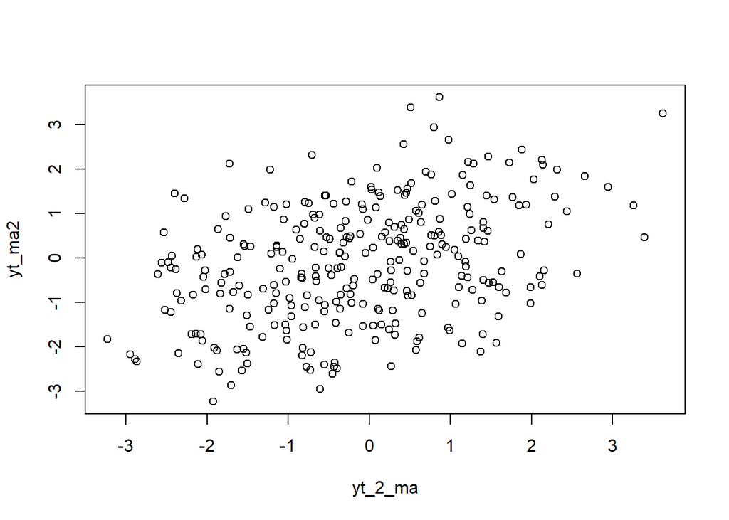

```r
plot(y=yt_ma2,x=yt_2_ma)
```

```r
cor(yt_ma2,yt_2_ma)
```

```
## [1] 0.3832821
```

#### WN Arima Sim

```r
#Yt
yt_ma2 <- ma2_asim[-c(1,2)]
yt_ma2
```

```
##   [1] -0.684887496 -1.601074080 -0.830008640 -0.061475942  0.059942893
##   [6]  0.629999510  0.455943655  0.981199262 -0.383578723  1.299353494
##  [11]  0.691720367  1.212400641  0.427279802 -1.427800045 -0.095873492
##  [16] -1.149723747  0.104118997 -1.363312548  1.613492588 -0.450220027
##  [21]  1.219695883  2.224596769  0.907259977  2.776777428  0.114107789
##  [26] -0.712501537 -1.005387383  0.272170905 -0.206995038  1.204158466
##  [31]  0.855353293 -0.136128945 -1.471874261 -3.776029949 -1.615557493
##  [36] -1.587495463 -0.877474742 -0.976265978  1.181286061  0.518771173
##  [41]  0.868617460 -0.068095779 -1.564497825 -2.185247721 -1.309832062
##  [46] -0.024538917 -0.399117245 -0.029898486  2.729444927  2.232459248
##  [51]  2.086031182 -0.855561214 -0.797571690 -0.504299895  1.685951163
##  [56]  1.455789330  0.715196561 -0.412462897 -1.935383335 -1.367063932
##  [61] -1.646282322  1.115311882 -0.454086727  2.856542760  1.387610751
##  [66]  1.648831050  1.430208314  1.355924982  3.228220785  1.926963263
##  [71]  2.482365237  1.020093686  0.513956475  1.796005999  1.441943621
```

[output cut: 45 more lines]

```r
#Yt-2
yt_2_ma <- ma2_asim[-c(299,300)]
yt_2_ma
```

```
##   [1]  0.763294353  1.063718638 -0.684887496 -1.601074080 -0.830008640
##   [6] -0.061475942  0.059942893  0.629999510  0.455943655  0.981199262
##  [11] -0.383578723  1.299353494  0.691720367  1.212400641  0.427279802
##  [16] -1.427800045 -0.095873492 -1.149723747  0.104118997 -1.363312548
##  [21]  1.613492588 -0.450220027  1.219695883  2.224596769  0.907259977
##  [26]  2.776777428  0.114107789 -0.712501537 -1.005387383  0.272170905
##  [31] -0.206995038  1.204158466  0.855353293 -0.136128945 -1.471874261
##  [36] -3.776029949 -1.615557493 -1.587495463 -0.877474742 -0.976265978
##  [41]  1.181286061  0.518771173  0.868617460 -0.068095779 -1.564497825
##  [46] -2.185247721 -1.309832062 -0.024538917 -0.399117245 -0.029898486
##  [51]  2.729444927  2.232459248  2.086031182 -0.855561214 -0.797571690
##  [56] -0.504299895  1.685951163  1.455789330  0.715196561 -0.412462897
##  [61] -1.935383335 -1.367063932 -1.646282322  1.115311882 -0.454086727
##  [66]  2.856542760  1.387610751  1.648831050  1.430208314  1.355924982
##  [71]  3.228220785  1.926963263  2.482365237  1.020093686  0.513956475
```

[output cut: 45 more lines]

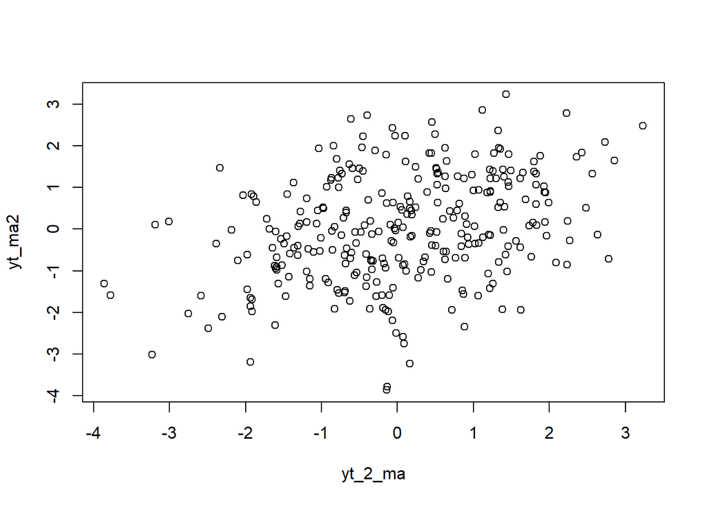

```r
plot(y=yt_ma2,x=yt_2_ma)
```

```r
cor(yt_ma2,yt_2_ma)
```

```
## [1] 0.3370002
```

### Korelasi antara $Y_t$ dengan $Y_{t-3}$

#### WN Manual

```r
#Yt
yt_ma3 <- ma2_manual[-c(1,2, 3)]
yt_ma3
```

```
##   [1] -2.28131581  0.04979783  1.33925571  0.23138443  0.39808939 -0.67609116
##   [7]  0.31830540  0.24265002 -1.72772200 -1.60555190 -1.14153844 -0.61361823
##  [13]  0.25018905  0.97865501  0.38226453  2.65749453  0.45662382  1.84907204
##  [19]  1.46355736  1.18250454  2.28758982 -0.08011880  1.38739886 -1.53900503
##  [25] -0.96452384  0.27173118 -1.31640965 -0.28021640 -1.77270601 -0.67481978
##  [31]  0.94447600  0.90102582  0.24202944  0.30926610  0.80006017  0.69839663
##  [37]  2.94687445  1.93686808  1.60217842  1.19468198 -0.66106659 -0.18891591
##  [43] -0.41319555 -0.46840017 -1.46356464 -0.39007762  0.26546056 -0.23113749
##  [49] -0.07762227 -0.81730710 -1.03849780 -1.55372803 -1.49112108  0.30297346
##  [55]  1.10495406 -0.72787447 -0.65678167 -2.51955200 -0.52482895 -1.17298937
##  [61]  0.46783023  1.15379901  1.56997342  1.86560381 -1.90949931  0.09421027
##  [67] -2.01842829  2.03028730 -0.70680325  1.76569228  2.31529166  1.37139143
##  [73]  1.98878093 -2.11159228 -1.02131523 -2.38559442  1.21191125 -0.25216118
##  [79]  1.14441919 -1.67616506 -1.92747164 -0.76486810 -3.23034915 -0.84349546
##  [85] -1.82305568 -0.43616944 -0.55477878 -2.44952645 -2.39964816 -1.22127574
```

[output cut: 35 more lines]

```r
#Yt-2
yt_3_ma <- ma2_manual[-c(298,299,300)]
yt_3_ma
```

```
##   [1]  0.26769450 -2.88626505 -2.43676294 -2.28131581  0.04979783  1.33925571
##   [7]  0.23138443  0.39808939 -0.67609116  0.31830540  0.24265002 -1.72772200
##  [13] -1.60555190 -1.14153844 -0.61361823  0.25018905  0.97865501  0.38226453
##  [19]  2.65749453  0.45662382  1.84907204  1.46355736  1.18250454  2.28758982
##  [25] -0.08011880  1.38739886 -1.53900503 -0.96452384  0.27173118 -1.31640965
##  [31] -0.28021640 -1.77270601 -0.67481978  0.94447600  0.90102582  0.24202944
##  [37]  0.30926610  0.80006017  0.69839663  2.94687445  1.93686808  1.60217842
##  [43]  1.19468198 -0.66106659 -0.18891591 -0.41319555 -0.46840017 -1.46356464
##  [49] -0.39007762  0.26546056 -0.23113749 -0.07762227 -0.81730710 -1.03849780
##  [55] -1.55372803 -1.49112108  0.30297346  1.10495406 -0.72787447 -0.65678167
##  [61] -2.51955200 -0.52482895 -1.17298937  0.46783023  1.15379901  1.56997342
##  [67]  1.86560381 -1.90949931  0.09421027 -2.01842829  2.03028730 -0.70680325
##  [73]  1.76569228  2.31529166  1.37139143  1.98878093 -2.11159228 -1.02131523
##  [79] -2.38559442  1.21191125 -0.25216118  1.14441919 -1.67616506 -1.92747164
##  [85] -0.76486810 -3.23034915 -0.84349546 -1.82305568 -0.43616944 -0.55477878
```

[output cut: 35 more lines]

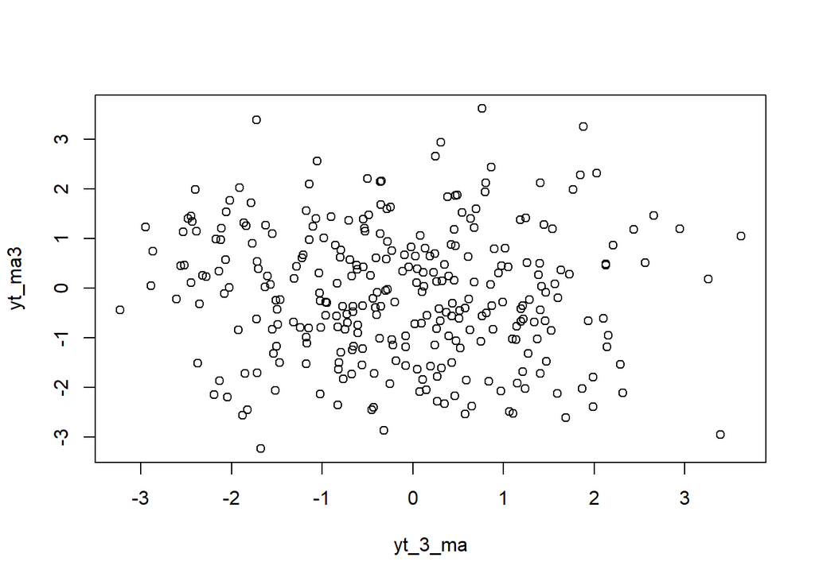

```r
plot(y=yt_ma3,x=yt_3_ma)
```

```r
cor(yt_ma3,yt_3_ma)
```

```
## [1] -0.07046001
```

#### WN Arima Sim

```r
#Yt
yt_ma3 <- ma2_asim[-c(1,2,3)]
yt_ma3
```

```
##   [1] -1.601074080 -0.830008640 -0.061475942  0.059942893  0.629999510
##   [6]  0.455943655  0.981199262 -0.383578723  1.299353494  0.691720367
##  [11]  1.212400641  0.427279802 -1.427800045 -0.095873492 -1.149723747
##  [16]  0.104118997 -1.363312548  1.613492588 -0.450220027  1.219695883
##  [21]  2.224596769  0.907259977  2.776777428  0.114107789 -0.712501537
##  [26] -1.005387383  0.272170905 -0.206995038  1.204158466  0.855353293
##  [31] -0.136128945 -1.471874261 -3.776029949 -1.615557493 -1.587495463
##  [36] -0.877474742 -0.976265978  1.181286061  0.518771173  0.868617460
##  [41] -0.068095779 -1.564497825 -2.185247721 -1.309832062 -0.024538917
##  [46] -0.399117245 -0.029898486  2.729444927  2.232459248  2.086031182
##  [51] -0.855561214 -0.797571690 -0.504299895  1.685951163  1.455789330
##  [56]  0.715196561 -0.412462897 -1.935383335 -1.367063932 -1.646282322
##  [61]  1.115311882 -0.454086727  2.856542760  1.387610751  1.648831050
##  [66]  1.430208314  1.355924982  3.228220785  1.926963263  2.482365237
##  [71]  1.020093686  0.513956475  1.796005999  1.441943621  1.382594254
```

[output cut: 45 more lines]

```r
#Yt-2
yt_3_ma <- ma2_asim[-c(298,299,300)]
yt_3_ma
```

```
##   [1]  0.763294353  1.063718638 -0.684887496 -1.601074080 -0.830008640
##   [6] -0.061475942  0.059942893  0.629999510  0.455943655  0.981199262
##  [11] -0.383578723  1.299353494  0.691720367  1.212400641  0.427279802
##  [16] -1.427800045 -0.095873492 -1.149723747  0.104118997 -1.363312548
##  [21]  1.613492588 -0.450220027  1.219695883  2.224596769  0.907259977
##  [26]  2.776777428  0.114107789 -0.712501537 -1.005387383  0.272170905
##  [31] -0.206995038  1.204158466  0.855353293 -0.136128945 -1.471874261
##  [36] -3.776029949 -1.615557493 -1.587495463 -0.877474742 -0.976265978
##  [41]  1.181286061  0.518771173  0.868617460 -0.068095779 -1.564497825
##  [46] -2.185247721 -1.309832062 -0.024538917 -0.399117245 -0.029898486
##  [51]  2.729444927  2.232459248  2.086031182 -0.855561214 -0.797571690
##  [56] -0.504299895  1.685951163  1.455789330  0.715196561 -0.412462897
##  [61] -1.935383335 -1.367063932 -1.646282322  1.115311882 -0.454086727
##  [66]  2.856542760  1.387610751  1.648831050  1.430208314  1.355924982
##  [71]  3.228220785  1.926963263  2.482365237  1.020093686  0.513956475
```

[output cut: 45 more lines]

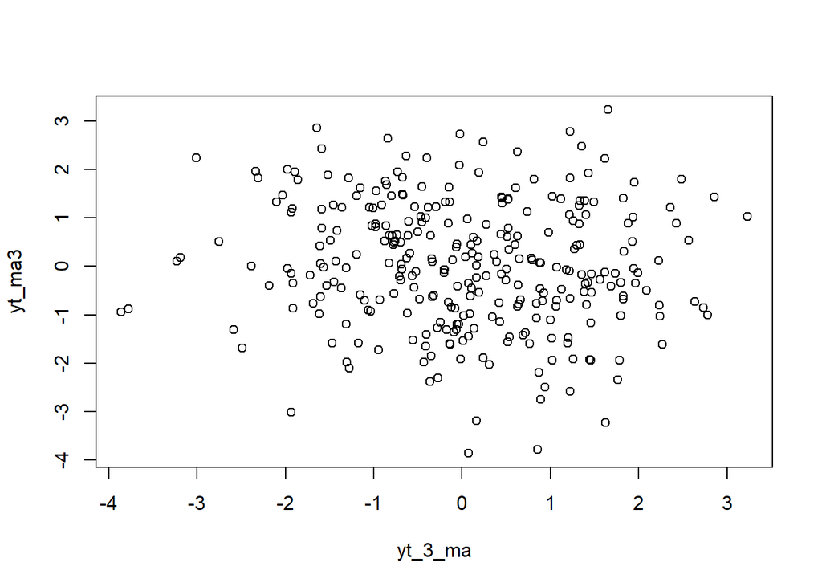

```r
plot(y=yt_ma3,x=yt_3_ma)
```

```r
cor(yt_ma3,yt_3_ma)
```

```
## [1] -0.1003552
```

## Nilai Autokorelasi

### Dari Data Bangkitan

#### WN Manual

```r
acf_manual <- acf(ma2_manual, lag.max = 10, plot = FALSE)
acf_manual$acf
```

```
## , , 1
##
##               [,1]
##  [1,]  1.000000000
##  [2,]  0.391876164
##  [3,]  0.379005900
##  [4,] -0.069385725
##  [5,]  0.005611914
##  [6,]  0.057368606
##  [7,]  0.082910580
##  [8,]  0.133100979
##  [9,] -0.009274114
## [10,] -0.008890951
## [11,] -0.151588670
```

#### WN Arima.sim

```r
acf_asim <- acf(ma2_asim, lag.max = 10, plot = FALSE)
acf_asim$acf
```

```
## , , 1
##
##               [,1]
##  [1,]  1.000000000
##  [2,]  0.446995314
##  [3,]  0.335878896
##  [4,] -0.099844754
##  [5,] -0.150685450
##  [6,] -0.125357699
##  [7,] -0.088648607
##  [8,]  0.001939679
##  [9,]  0.017903834
## [10,]  0.073170869
## [11,]  0.008879419
```

### Secara Teoritis

#### WN Manual

```r
# Varians white noise
sigma2 <- 1

# Autokovarians
gamma0 <- sigma2 * (1 + theta1^2 + theta2^2)
gamma1 <- sigma2 * (theta1 + theta1*theta2)
gamma2 <- sigma2 * (theta2)

# Autokorelasi teoritis
rho0 <- gamma0 / gamma0
rho1 <- gamma1 / gamma0
rho2 <- gamma2 / gamma0
rho_lain <- 0   # untuk lag > 2

rho_teori <- c(rho0, rho1, rho2, rep(0, 7)) # sampai lag 9
rho_teori
```

```
##  [1] 1.0000000 0.4210526 0.3947368 0.0000000 0.0000000 0.0000000 0.0000000
##  [8] 0.0000000 0.0000000 0.0000000
```

### Kesimpulan

```r
data.frame(
  Lag = 0:9,
  Empiris_Manual = round(acf_manual$acf[1:10], 3),
  Empiris_ArimaSim = round(acf_asim$acf[1:10], 3),
  Teoritis = round(rho_teori, 3)
)
```

```
##    Lag Empiris_Manual Empiris_ArimaSim Teoritis
## 1    0          1.000            1.000    1.000
## 2    1          0.392            0.447    0.421
## 3    2          0.379            0.336    0.395
## 4    3         -0.069           -0.100    0.000
## 5    4          0.006           -0.151    0.000
## 6    5          0.057           -0.125    0.000
## 7    6          0.083           -0.089    0.000
## 8    7          0.133            0.002    0.000
## 9    8         -0.009            0.018    0.000
## 10   9         -0.009            0.073    0.000
```

Berdasarkan hasil perhitungan, autokorelasi pada lag 0 bernilai 1 sesuai definisi. Pada lag 1 dan 2, nilai empiris (baik manual maupun arima.sim) menunjukkan autokorelasi positif yang mendekati nilai teoritis (ρ₁ ≈ 0.421 dan ρ₂ ≈ 0.395), sesuai karakteristik proses MA(2). Untuk lag lebih dari 2, secara teoritis autokorelasi bernilai nol, sementara hasil empiris masih menunjukkan fluktuasi kecil di sekitar nol akibat faktor acak dan keterbatasan jumlah sampel. Secara keseluruhan, data bangkitan konsisten dengan sifat teoritis MA(2).

# Kasus 2 - AR(2)

## Pembangkitan Data

### Manual

```r
set.seed(1061)
n <- 300
wn <- rnorm(n, mean = 0, sd = 1)

phi1 <- 0.5
phi2 <- 0.2

ar2_manual <- numeric(n)
ar2_manual[1:2] <- wn[1:2]

for(i in 3:n){
  ar2_manual[i] <- wn[i] + phi1*ar2_manual[i-1] + phi2*ar2_manual[i-2]
}

ar2_manual
```

```
##   [1]  1.48559382 -1.23176993 -0.44972002 -2.56603556 -2.89322381 -2.37613708
##   [7] -0.63823103  0.34331071 -0.85675724 -0.28391272 -0.47926064  0.04279141
##  [13]  0.13208359 -1.93926050 -1.86714521 -0.88507413 -1.04976556 -0.61999912
##  [19]  0.56622261  0.05776680  2.18845516  0.80468067  1.58174717  2.29934092
##  [25]  1.66448247  2.69179549  0.91972346  1.84943635 -0.31538590 -0.69343932
##  [31]  1.07861706 -0.96777436 -0.89407050 -1.34189643 -0.86851553  0.67012402
##  [37]  0.52453223 -0.33060561  0.32172436  1.17809086  0.68917458  2.86275632
##  [43]  2.57159025  1.69004342  2.01991662  0.52365144  0.41027324  0.49347501
##  [49] -0.05972977 -1.34949062 -0.27632743  0.54424563 -0.64142145 -0.51755684
##  [55] -0.56712445 -1.17012955 -1.83095827 -1.71780511 -0.01531956  0.61080344
##  [61] -1.53621115 -1.14452152 -2.09649496 -1.01603796 -1.47455769 -0.41042861
##  [67]  0.76999386  1.04680205  1.48337544 -1.72717594  0.11500163 -0.97219403
##  [73]  1.43174577 -0.53275036  1.07043456  2.95628530  1.42229741  1.88258870
##  [79] -0.95595233 -0.59820095 -1.36816465  1.05738374 -0.21482052  0.31977370
##  [85] -1.36359752 -2.08253188 -0.60466624 -3.35410361 -2.01296639 -1.83320859
```

[output cut: 35 more lines]

```r
length(ar2_manual)
```

```
## [1] 300
```

### WN Arima.sim

```r
set.seed(1061)
ar2_asim <- arima.sim(list(order = c(2,0,0), ar = c(0.5, 0.2)), n = 300)
ar2_asim
```

```
## Time Series:
## Start = 1
## End = 300
## Frequency = 1
##   [1]  2.69261604  0.92034900  1.84991323 -0.31502235 -0.69316218  1.07882834
##   [7] -0.96761329 -0.89394771 -1.34180282 -0.86844417  0.67017843  0.52457370
##  [13] -0.33057399  0.32174846  1.17810924  0.68918858  2.86276700  2.57159839
##  [19]  1.69004963  2.01992135  0.52365505  0.41027599  0.49347711 -0.05972817
##  [25] -1.34948940 -0.27632651  0.54424634 -0.64142091 -0.51755643 -0.56712414
##  [31] -1.17012931 -1.83095809 -1.71780497 -0.01531945  0.61080352 -1.53621109
##  [37] -1.14452147 -2.09649493 -1.01603794 -1.47455767 -0.41042860  0.76999387
##  [43]  1.04680206  1.48337545 -1.72717594  0.11500163 -0.97219403  1.43174577
##  [49] -0.53275036  1.07043456  2.95628530  1.42229741  1.88258870 -0.95595233
##  [55] -0.59820095 -1.36816465  1.05738374 -0.21482052  0.31977370 -1.36359752
##  [61] -2.08253188 -0.60466624 -3.35410361 -2.01296639 -1.83320859 -1.56401634
```

[output cut: 39 more lines]

```r
length(ar2_asim)
```

```
## [1] 300
```

## Karakteristik AR(2)

### Plot Time Series

#### WN Manual

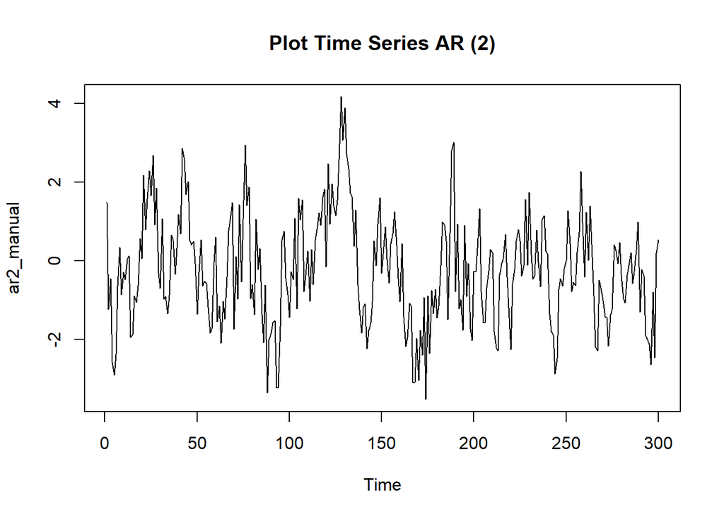

```r
ts.plot(ar2_manual, main = "Plot Time Series AR (2)")
```

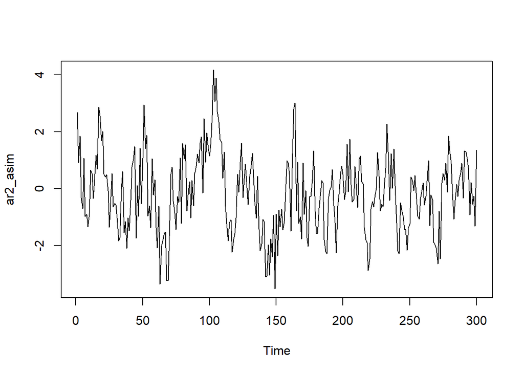

```r
ts.plot(ar2_asim)
```

Berdasarkan plot time series tersebut terlihat bahwa data cenderung stasioner pada rataan

### Plot ACF

#### WN Manual

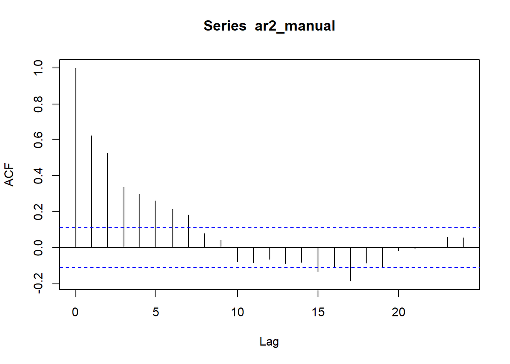

```r
acf(ar2_manual)
```

Berdasarkan plot ACF tersebut terlihat bahwa plot ACF cenderung *tails off* dan cenderung membentuk pola grafik sinusodial

#### WN Arima.sim

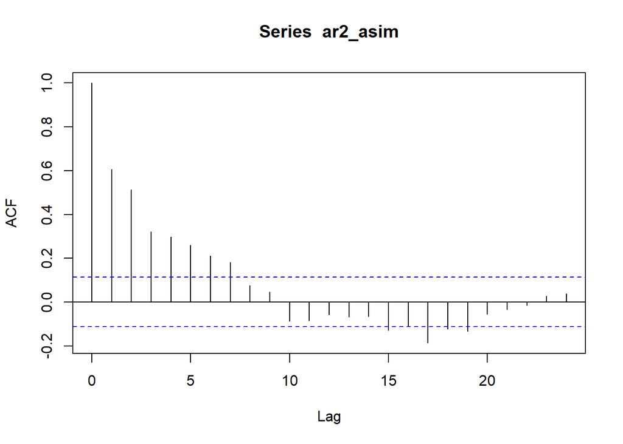

```r
acf(ar2_asim)
```

Berdasarkan plot ACF tersebut terlihat bahwa plot ACF cenderung *tails off* dan cenderung membentuk pola grafik sinusoidal

### Plot PACF

#### WN Manual

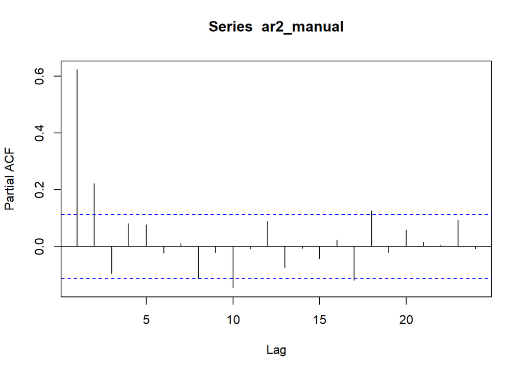

```r
pacf(ar2_manual)
```

Berdasarkan plot PACF tersebut, terlihat bahwa plot PACF *cuts off* pada lag kedua, sejalan dengan teori yang ada

#### WN Arima.sim

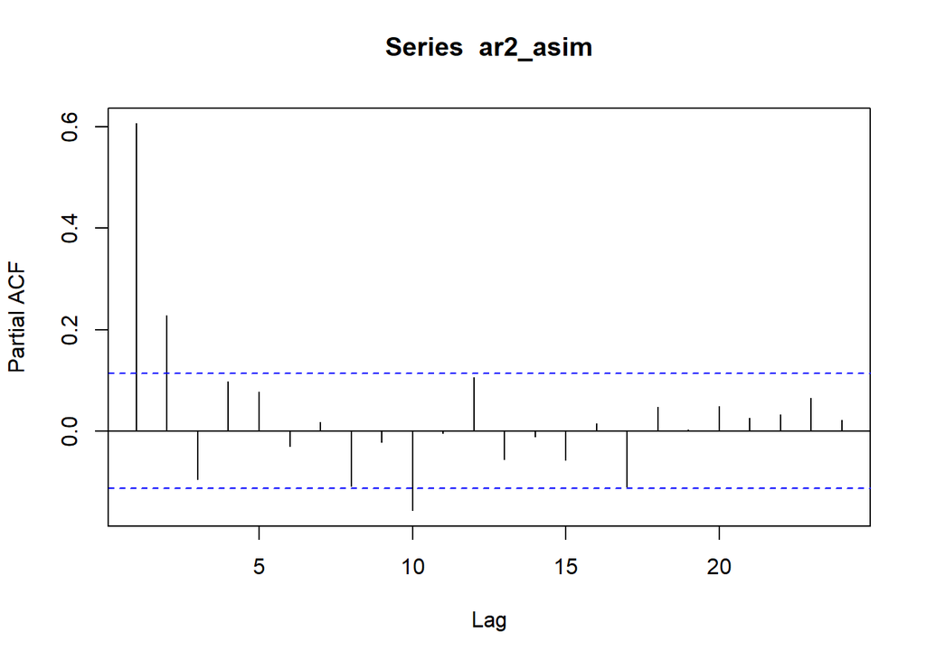

```r
pacf(ar2_asim)
```

Berdasarkan plot PACF tersebut, terlihat bahwa plot PACF *cuts off* pada lag kedua

### Plot EACF

#### WN Manual

```r
TSA::eacf(ar2_manual)
```

```
## AR/MA
##   0 1 2 3 4 5 6 7 8 9 10 11 12 13
## 0 x x x x x x x o o o o  o  o  o
## 1 x x x o o o x o o x o  o  o  o
## 2 x o x o o o x o o x x  o  o  o
## 3 x x x o o o o o x x x  o  o  o
## 4 x x x o o o o o o x o  o  o  o
## 5 x o x x o o o o o x x  o  o  o
## 6 x o x o o o o o o o x  o  o  o
## 7 x x x x o x o o x o x  o  o  o
```

```r
TSA::eacf(ar2_asim)
```

```
## AR/MA
##   0 1 2 3 4 5 6 7 8 9 10 11 12 13
## 0 x x x x x x x o o o o  o  o  o
## 1 x x x o o o x o o x o  o  o  o
## 2 x o x o o o x o o x x  o  o  o
## 3 x x x o o o o o x x o  o  o  o
## 4 x x x o o o o o o x o  o  o  o
## 5 x o o x o o o o o o x  o  o  o
## 6 x o o o o o o o o o x  o  o  o
## 7 x x x x o x o o x o x  o  o  o
```

### Kesimpulan

Berdasarkan plot time series, ACF, dan PACF, data hasil simulasi (baik manual maupun dengan arima.sim) dapat dikatakan stasioner. Tidak terdapat indikasi tren atau perubahan varians, dan pola ACF/PACF sesuai dengan karakteristik proses AR(2).

## Scatterplot Antar Lag

### Korelasi antara $Y_t$ dengan $Y_{t-1}$

#### WN Manual

```r
#Yt
yt_ar <- ar2_manual[-1]
yt_ar
```

```
##   [1] -1.23176993 -0.44972002 -2.56603556 -2.89322381 -2.37613708 -0.63823103
##   [7]  0.34331071 -0.85675724 -0.28391272 -0.47926064  0.04279141  0.13208359
##  [13] -1.93926050 -1.86714521 -0.88507413 -1.04976556 -0.61999912  0.56622261
##  [19]  0.05776680  2.18845516  0.80468067  1.58174717  2.29934092  1.66448247
##  [25]  2.69179549  0.91972346  1.84943635 -0.31538590 -0.69343932  1.07861706
##  [31] -0.96777436 -0.89407050 -1.34189643 -0.86851553  0.67012402  0.52453223
##  [37] -0.33060561  0.32172436  1.17809086  0.68917458  2.86275632  2.57159025
##  [43]  1.69004342  2.01991662  0.52365144  0.41027324  0.49347501 -0.05972977
##  [49] -1.34949062 -0.27632743  0.54424563 -0.64142145 -0.51755684 -0.56712445
##  [55] -1.17012955 -1.83095827 -1.71780511 -0.01531956  0.61080344 -1.53621115
##  [61] -1.14452152 -2.09649496 -1.01603796 -1.47455769 -0.41042861  0.76999386
##  [67]  1.04680205  1.48337544 -1.72717594  0.11500163 -0.97219403  1.43174577
##  [73] -0.53275036  1.07043456  2.95628530  1.42229741  1.88258870 -0.95595233
##  [79] -0.59820095 -1.36816465  1.05738374 -0.21482052  0.31977370 -1.36359752
##  [85] -2.08253188 -0.60466624 -3.35410361 -2.01296639 -1.83320859 -1.56401634
```

[output cut: 35 more lines]

```r
#Yt-1
yt_1_ar <- ar2_manual[-300]
yt_1_ar
```

```
##   [1]  1.48559382 -1.23176993 -0.44972002 -2.56603556 -2.89322381 -2.37613708
##   [7] -0.63823103  0.34331071 -0.85675724 -0.28391272 -0.47926064  0.04279141
##  [13]  0.13208359 -1.93926050 -1.86714521 -0.88507413 -1.04976556 -0.61999912
##  [19]  0.56622261  0.05776680  2.18845516  0.80468067  1.58174717  2.29934092
##  [25]  1.66448247  2.69179549  0.91972346  1.84943635 -0.31538590 -0.69343932
##  [31]  1.07861706 -0.96777436 -0.89407050 -1.34189643 -0.86851553  0.67012402
##  [37]  0.52453223 -0.33060561  0.32172436  1.17809086  0.68917458  2.86275632
##  [43]  2.57159025  1.69004342  2.01991662  0.52365144  0.41027324  0.49347501
##  [49] -0.05972977 -1.34949062 -0.27632743  0.54424563 -0.64142145 -0.51755684
##  [55] -0.56712445 -1.17012955 -1.83095827 -1.71780511 -0.01531956  0.61080344
##  [61] -1.53621115 -1.14452152 -2.09649496 -1.01603796 -1.47455769 -0.41042861
##  [67]  0.76999386  1.04680205  1.48337544 -1.72717594  0.11500163 -0.97219403
##  [73]  1.43174577 -0.53275036  1.07043456  2.95628530  1.42229741  1.88258870
##  [79] -0.95595233 -0.59820095 -1.36816465  1.05738374 -0.21482052  0.31977370
##  [85] -1.36359752 -2.08253188 -0.60466624 -3.35410361 -2.01296639 -1.83320859
```

[output cut: 35 more lines]

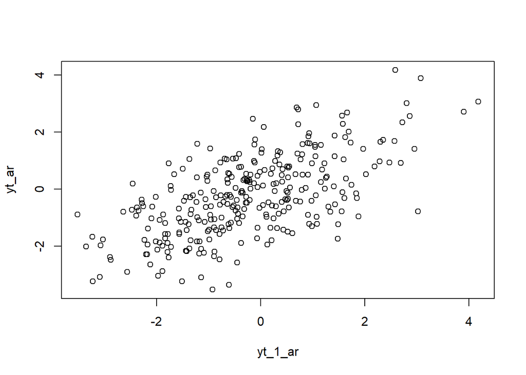

```r
plot(y=yt_ar,x=yt_1_ar)
```

```r
cor(yt_ar,yt_1_ar)
```

```
## [1] 0.6253167
```

#### WN Arima.sim

```r
#Yt
yt_ar <- ar2_asim[-1]
yt_ar
```

```
##   [1]  0.92034900  1.84991323 -0.31502235 -0.69316218  1.07882834 -0.96761329
##   [7] -0.89394771 -1.34180282 -0.86844417  0.67017843  0.52457370 -0.33057399
##  [13]  0.32174846  1.17810924  0.68918858  2.86276700  2.57159839  1.69004963
##  [19]  2.01992135  0.52365505  0.41027599  0.49347711 -0.05972817 -1.34948940
##  [25] -0.27632651  0.54424634 -0.64142091 -0.51755643 -0.56712414 -1.17012931
##  [31] -1.83095809 -1.71780497 -0.01531945  0.61080352 -1.53621109 -1.14452147
##  [37] -2.09649493 -1.01603794 -1.47455767 -0.41042860  0.76999387  1.04680206
##  [43]  1.48337545 -1.72717594  0.11500163 -0.97219403  1.43174577 -0.53275036
##  [49]  1.07043456  2.95628530  1.42229741  1.88258870 -0.95595233 -0.59820095
##  [55] -1.36816465  1.05738374 -0.21482052  0.31977370 -1.36359752 -2.08253188
##  [61] -0.60466624 -3.35410361 -2.01296639 -1.83320859 -1.56401634 -1.51195836
##  [67] -3.22609425 -3.23417716 -1.66170074  0.53115088  0.75779515 -0.43391809
##  [73] -0.85304103 -1.43112337 -0.26362674 -0.47373978  1.08605619 -1.21370818
##  [79]  1.59488018  1.04455472  1.56017834 -0.76919161 -0.20866359  0.24722726
##  [85] -1.01813622  0.29070445 -0.60008156  0.54583736  0.80066242  1.22262497
```

[output cut: 35 more lines]

```r
#Yt-1
yt_1_ar <- ar2_asim[-300]
yt_1_ar
```

```
##   [1]  2.69261604  0.92034900  1.84991323 -0.31502235 -0.69316218  1.07882834
##   [7] -0.96761329 -0.89394771 -1.34180282 -0.86844417  0.67017843  0.52457370
##  [13] -0.33057399  0.32174846  1.17810924  0.68918858  2.86276700  2.57159839
##  [19]  1.69004963  2.01992135  0.52365505  0.41027599  0.49347711 -0.05972817
##  [25] -1.34948940 -0.27632651  0.54424634 -0.64142091 -0.51755643 -0.56712414
##  [31] -1.17012931 -1.83095809 -1.71780497 -0.01531945  0.61080352 -1.53621109
##  [37] -1.14452147 -2.09649493 -1.01603794 -1.47455767 -0.41042860  0.76999387
##  [43]  1.04680206  1.48337545 -1.72717594  0.11500163 -0.97219403  1.43174577
##  [49] -0.53275036  1.07043456  2.95628530  1.42229741  1.88258870 -0.95595233
##  [55] -0.59820095 -1.36816465  1.05738374 -0.21482052  0.31977370 -1.36359752
##  [61] -2.08253188 -0.60466624 -3.35410361 -2.01296639 -1.83320859 -1.56401634
##  [67] -1.51195836 -3.22609425 -3.23417716 -1.66170074  0.53115088  0.75779515
##  [73] -0.43391809 -0.85304103 -1.43112337 -0.26362674 -0.47373978  1.08605619
##  [79] -1.21370818  1.59488018  1.04455472  1.56017834 -0.76919161 -0.20866359
##  [85]  0.24722726 -1.01813622  0.29070445 -0.60008156  0.54583736  0.80066242
```

[output cut: 35 more lines]

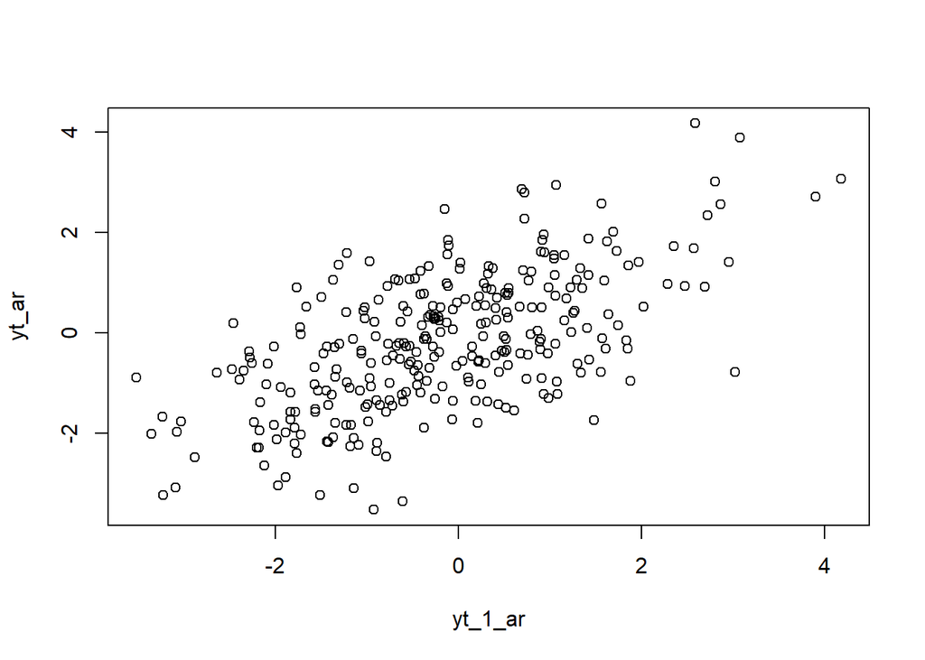

```r
plot(y=yt_ar,x=yt_1_ar)
```

```r
cor(yt_ar,yt_1_ar)
```

```
## [1] 0.6127163
```

### Korelasi antara $Y_t$ dengan $Y_{t-2}$

#### WN Manual

```r
#Yt
yt_ar2 <- ar2_manual[-c(1,2)]
yt_ar2
```

```
##   [1] -0.44972002 -2.56603556 -2.89322381 -2.37613708 -0.63823103  0.34331071
##   [7] -0.85675724 -0.28391272 -0.47926064  0.04279141  0.13208359 -1.93926050
##  [13] -1.86714521 -0.88507413 -1.04976556 -0.61999912  0.56622261  0.05776680
##  [19]  2.18845516  0.80468067  1.58174717  2.29934092  1.66448247  2.69179549
##  [25]  0.91972346  1.84943635 -0.31538590 -0.69343932  1.07861706 -0.96777436
##  [31] -0.89407050 -1.34189643 -0.86851553  0.67012402  0.52453223 -0.33060561
##  [37]  0.32172436  1.17809086  0.68917458  2.86275632  2.57159025  1.69004342
##  [43]  2.01991662  0.52365144  0.41027324  0.49347501 -0.05972977 -1.34949062
##  [49] -0.27632743  0.54424563 -0.64142145 -0.51755684 -0.56712445 -1.17012955
##  [55] -1.83095827 -1.71780511 -0.01531956  0.61080344 -1.53621115 -1.14452152
##  [61] -2.09649496 -1.01603796 -1.47455769 -0.41042861  0.76999386  1.04680205
##  [67]  1.48337544 -1.72717594  0.11500163 -0.97219403  1.43174577 -0.53275036
##  [73]  1.07043456  2.95628530  1.42229741  1.88258870 -0.95595233 -0.59820095
##  [79] -1.36816465  1.05738374 -0.21482052  0.31977370 -1.36359752 -2.08253188
##  [85] -0.60466624 -3.35410361 -2.01296639 -1.83320859 -1.56401634 -1.51195836
```

[output cut: 35 more lines]

```r
#Yt-2
yt_2_ar <- ar2_manual[-c(299,300)]
yt_2_ar
```

```
##   [1]  1.48559382 -1.23176993 -0.44972002 -2.56603556 -2.89322381 -2.37613708
##   [7] -0.63823103  0.34331071 -0.85675724 -0.28391272 -0.47926064  0.04279141
##  [13]  0.13208359 -1.93926050 -1.86714521 -0.88507413 -1.04976556 -0.61999912
##  [19]  0.56622261  0.05776680  2.18845516  0.80468067  1.58174717  2.29934092
##  [25]  1.66448247  2.69179549  0.91972346  1.84943635 -0.31538590 -0.69343932
##  [31]  1.07861706 -0.96777436 -0.89407050 -1.34189643 -0.86851553  0.67012402
##  [37]  0.52453223 -0.33060561  0.32172436  1.17809086  0.68917458  2.86275632
##  [43]  2.57159025  1.69004342  2.01991662  0.52365144  0.41027324  0.49347501
##  [49] -0.05972977 -1.34949062 -0.27632743  0.54424563 -0.64142145 -0.51755684
##  [55] -0.56712445 -1.17012955 -1.83095827 -1.71780511 -0.01531956  0.61080344
##  [61] -1.53621115 -1.14452152 -2.09649496 -1.01603796 -1.47455769 -0.41042861
##  [67]  0.76999386  1.04680205  1.48337544 -1.72717594  0.11500163 -0.97219403
##  [73]  1.43174577 -0.53275036  1.07043456  2.95628530  1.42229741  1.88258870
##  [79] -0.95595233 -0.59820095 -1.36816465  1.05738374 -0.21482052  0.31977370
##  [85] -1.36359752 -2.08253188 -0.60466624 -3.35410361 -2.01296639 -1.83320859
```

[output cut: 35 more lines]

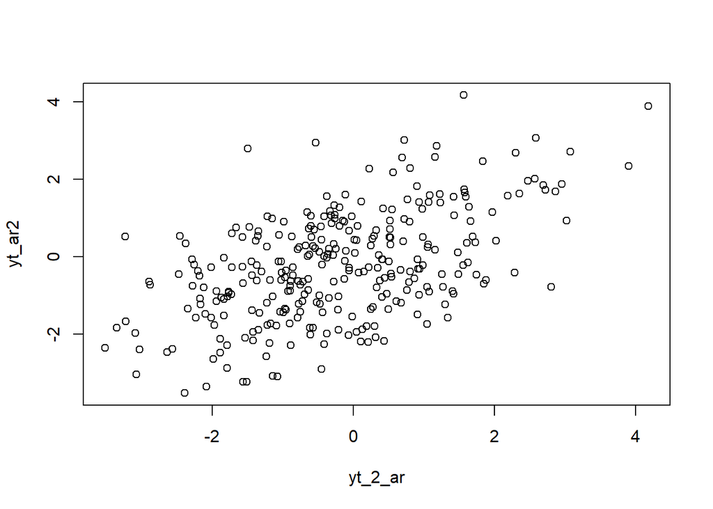

```r
plot(y=yt_ar2,x=yt_2_ar)
```

```r
cor(yt_ar2,yt_2_ar)
```

```
## [1] 0.5271201
```

#### WN Arima.sim

```r
#Yt
yt_ar2 <- ar2_asim[-c(1,2)]
yt_ar2
```

```
##   [1]  1.84991323 -0.31502235 -0.69316218  1.07882834 -0.96761329 -0.89394771
##   [7] -1.34180282 -0.86844417  0.67017843  0.52457370 -0.33057399  0.32174846
##  [13]  1.17810924  0.68918858  2.86276700  2.57159839  1.69004963  2.01992135
##  [19]  0.52365505  0.41027599  0.49347711 -0.05972817 -1.34948940 -0.27632651
##  [25]  0.54424634 -0.64142091 -0.51755643 -0.56712414 -1.17012931 -1.83095809
##  [31] -1.71780497 -0.01531945  0.61080352 -1.53621109 -1.14452147 -2.09649493
##  [37] -1.01603794 -1.47455767 -0.41042860  0.76999387  1.04680206  1.48337545
##  [43] -1.72717594  0.11500163 -0.97219403  1.43174577 -0.53275036  1.07043456
##  [49]  2.95628530  1.42229741  1.88258870 -0.95595233 -0.59820095 -1.36816465
##  [55]  1.05738374 -0.21482052  0.31977370 -1.36359752 -2.08253188 -0.60466624
##  [61] -3.35410361 -2.01296639 -1.83320859 -1.56401634 -1.51195836 -3.22609425
##  [67] -3.23417716 -1.66170074  0.53115088  0.75779515 -0.43391809 -0.85304103
##  [73] -1.43112337 -0.26362674 -0.47373978  1.08605619 -1.21370818  1.59488018
##  [79]  1.04455472  1.56017834 -0.76919161 -0.20866359  0.24722726 -1.01813622
##  [85]  0.29070445 -0.60008156  0.54583736  0.80066242  1.22262497  0.90532357
```

[output cut: 35 more lines]

```r
#Yt-2
yt_2_ar <- ar2_asim[-c(299,300)]
yt_2_ar
```

```
##   [1]  2.69261604  0.92034900  1.84991323 -0.31502235 -0.69316218  1.07882834
##   [7] -0.96761329 -0.89394771 -1.34180282 -0.86844417  0.67017843  0.52457370
##  [13] -0.33057399  0.32174846  1.17810924  0.68918858  2.86276700  2.57159839
##  [19]  1.69004963  2.01992135  0.52365505  0.41027599  0.49347711 -0.05972817
##  [25] -1.34948940 -0.27632651  0.54424634 -0.64142091 -0.51755643 -0.56712414
##  [31] -1.17012931 -1.83095809 -1.71780497 -0.01531945  0.61080352 -1.53621109
##  [37] -1.14452147 -2.09649493 -1.01603794 -1.47455767 -0.41042860  0.76999387
##  [43]  1.04680206  1.48337545 -1.72717594  0.11500163 -0.97219403  1.43174577
##  [49] -0.53275036  1.07043456  2.95628530  1.42229741  1.88258870 -0.95595233
##  [55] -0.59820095 -1.36816465  1.05738374 -0.21482052  0.31977370 -1.36359752
##  [61] -2.08253188 -0.60466624 -3.35410361 -2.01296639 -1.83320859 -1.56401634
##  [67] -1.51195836 -3.22609425 -3.23417716 -1.66170074  0.53115088  0.75779515
##  [73] -0.43391809 -0.85304103 -1.43112337 -0.26362674 -0.47373978  1.08605619
##  [79] -1.21370818  1.59488018  1.04455472  1.56017834 -0.76919161 -0.20866359
##  [85]  0.24722726 -1.01813622  0.29070445 -0.60008156  0.54583736  0.80066242
```

[output cut: 35 more lines]

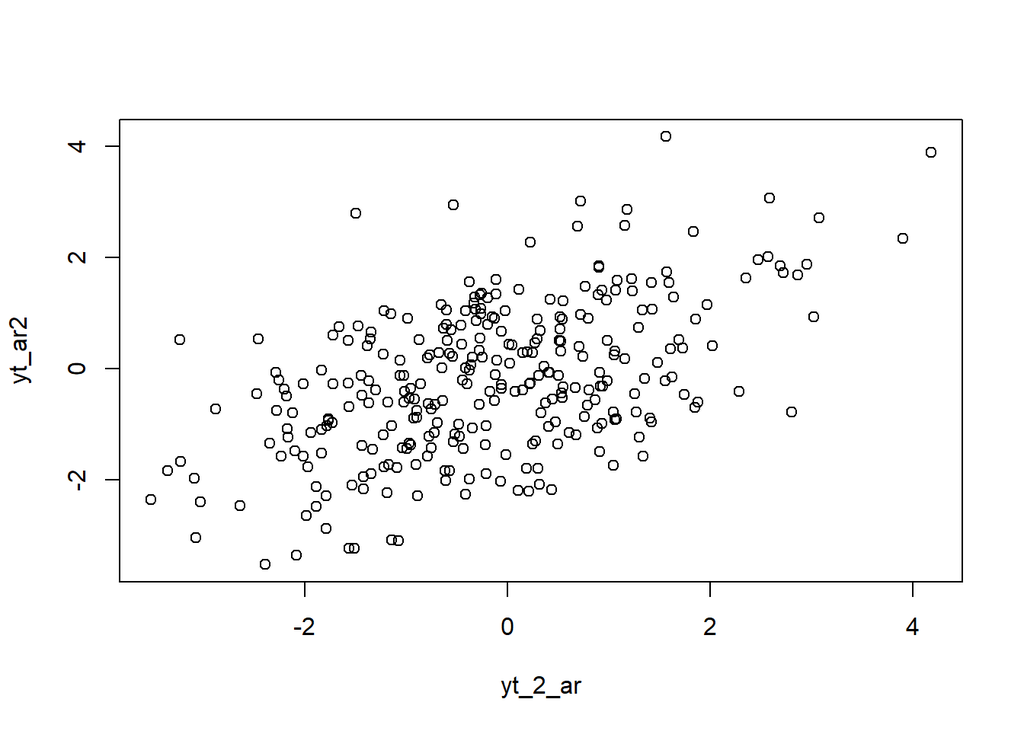

```r
plot(y=yt_ar2,x=yt_2_ar)
```

```r
cor(yt_ar2,yt_2_ar)
```

```
## [1] 0.5187049
```

### Korelasi antara $Y_t$ dengan $Y_{t-3}$

#### WN Manual

```r
#Yt
yt_ar3 <- ar2_manual[-c(1,2,3)]
yt_ar3
```

```
##   [1] -2.56603556 -2.89322381 -2.37613708 -0.63823103  0.34331071 -0.85675724
##   [7] -0.28391272 -0.47926064  0.04279141  0.13208359 -1.93926050 -1.86714521
##  [13] -0.88507413 -1.04976556 -0.61999912  0.56622261  0.05776680  2.18845516
##  [19]  0.80468067  1.58174717  2.29934092  1.66448247  2.69179549  0.91972346
##  [25]  1.84943635 -0.31538590 -0.69343932  1.07861706 -0.96777436 -0.89407050
##  [31] -1.34189643 -0.86851553  0.67012402  0.52453223 -0.33060561  0.32172436
##  [37]  1.17809086  0.68917458  2.86275632  2.57159025  1.69004342  2.01991662
##  [43]  0.52365144  0.41027324  0.49347501 -0.05972977 -1.34949062 -0.27632743
##  [49]  0.54424563 -0.64142145 -0.51755684 -0.56712445 -1.17012955 -1.83095827
##  [55] -1.71780511 -0.01531956  0.61080344 -1.53621115 -1.14452152 -2.09649496
##  [61] -1.01603796 -1.47455769 -0.41042861  0.76999386  1.04680205  1.48337544
##  [67] -1.72717594  0.11500163 -0.97219403  1.43174577 -0.53275036  1.07043456
##  [73]  2.95628530  1.42229741  1.88258870 -0.95595233 -0.59820095 -1.36816465
##  [79]  1.05738374 -0.21482052  0.31977370 -1.36359752 -2.08253188 -0.60466624
##  [85] -3.35410361 -2.01296639 -1.83320859 -1.56401634 -1.51195836 -3.22609425
```

[output cut: 35 more lines]

```r
#Yt-2
yt_3_ar <- ar2_manual[-c(298,299,300)]
yt_3_ar
```

```
##   [1]  1.48559382 -1.23176993 -0.44972002 -2.56603556 -2.89322381 -2.37613708
##   [7] -0.63823103  0.34331071 -0.85675724 -0.28391272 -0.47926064  0.04279141
##  [13]  0.13208359 -1.93926050 -1.86714521 -0.88507413 -1.04976556 -0.61999912
##  [19]  0.56622261  0.05776680  2.18845516  0.80468067  1.58174717  2.29934092
##  [25]  1.66448247  2.69179549  0.91972346  1.84943635 -0.31538590 -0.69343932
##  [31]  1.07861706 -0.96777436 -0.89407050 -1.34189643 -0.86851553  0.67012402
##  [37]  0.52453223 -0.33060561  0.32172436  1.17809086  0.68917458  2.86275632
##  [43]  2.57159025  1.69004342  2.01991662  0.52365144  0.41027324  0.49347501
##  [49] -0.05972977 -1.34949062 -0.27632743  0.54424563 -0.64142145 -0.51755684
##  [55] -0.56712445 -1.17012955 -1.83095827 -1.71780511 -0.01531956  0.61080344
##  [61] -1.53621115 -1.14452152 -2.09649496 -1.01603796 -1.47455769 -0.41042861
##  [67]  0.76999386  1.04680205  1.48337544 -1.72717594  0.11500163 -0.97219403
##  [73]  1.43174577 -0.53275036  1.07043456  2.95628530  1.42229741  1.88258870
##  [79] -0.95595233 -0.59820095 -1.36816465  1.05738374 -0.21482052  0.31977370
##  [85] -1.36359752 -2.08253188 -0.60466624 -3.35410361 -2.01296639 -1.83320859
```

[output cut: 35 more lines]

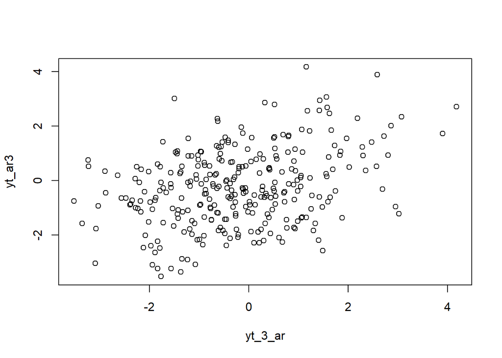

```r
plot(y=yt_ar3,x=yt_3_ar)
```

```r
cor(yt_ar3,yt_3_ar)
```

```
## [1] 0.340711
```

#### WN Arima.sim

```r
#Yt
yt_ar3 <- ar2_asim[-c(1,2,3)]
yt_ar3
```

```
##   [1] -0.31502235 -0.69316218  1.07882834 -0.96761329 -0.89394771 -1.34180282
##   [7] -0.86844417  0.67017843  0.52457370 -0.33057399  0.32174846  1.17810924
##  [13]  0.68918858  2.86276700  2.57159839  1.69004963  2.01992135  0.52365505
##  [19]  0.41027599  0.49347711 -0.05972817 -1.34948940 -0.27632651  0.54424634
##  [25] -0.64142091 -0.51755643 -0.56712414 -1.17012931 -1.83095809 -1.71780497
##  [31] -0.01531945  0.61080352 -1.53621109 -1.14452147 -2.09649493 -1.01603794
##  [37] -1.47455767 -0.41042860  0.76999387  1.04680206  1.48337545 -1.72717594
##  [43]  0.11500163 -0.97219403  1.43174577 -0.53275036  1.07043456  2.95628530
##  [49]  1.42229741  1.88258870 -0.95595233 -0.59820095 -1.36816465  1.05738374
##  [55] -0.21482052  0.31977370 -1.36359752 -2.08253188 -0.60466624 -3.35410361
##  [61] -2.01296639 -1.83320859 -1.56401634 -1.51195836 -3.22609425 -3.23417716
##  [67] -1.66170074  0.53115088  0.75779515 -0.43391809 -0.85304103 -1.43112337
##  [73] -0.26362674 -0.47373978  1.08605619 -1.21370818  1.59488018  1.04455472
##  [79]  1.56017834 -0.76919161 -0.20866359  0.24722726 -1.01813622  0.29070445
##  [85] -0.60008156  0.54583736  0.80066242  1.22262497  0.90532357  1.62276450
```

[output cut: 35 more lines]

```r
#Yt-2
yt_3_ar <- ar2_asim[-c(298,299,300)]
yt_3_ar
```

```
##   [1]  2.69261604  0.92034900  1.84991323 -0.31502235 -0.69316218  1.07882834
##   [7] -0.96761329 -0.89394771 -1.34180282 -0.86844417  0.67017843  0.52457370
##  [13] -0.33057399  0.32174846  1.17810924  0.68918858  2.86276700  2.57159839
##  [19]  1.69004963  2.01992135  0.52365505  0.41027599  0.49347711 -0.05972817
##  [25] -1.34948940 -0.27632651  0.54424634 -0.64142091 -0.51755643 -0.56712414
##  [31] -1.17012931 -1.83095809 -1.71780497 -0.01531945  0.61080352 -1.53621109
##  [37] -1.14452147 -2.09649493 -1.01603794 -1.47455767 -0.41042860  0.76999387
##  [43]  1.04680206  1.48337545 -1.72717594  0.11500163 -0.97219403  1.43174577
##  [49] -0.53275036  1.07043456  2.95628530  1.42229741  1.88258870 -0.95595233
##  [55] -0.59820095 -1.36816465  1.05738374 -0.21482052  0.31977370 -1.36359752
##  [61] -2.08253188 -0.60466624 -3.35410361 -2.01296639 -1.83320859 -1.56401634
##  [67] -1.51195836 -3.22609425 -3.23417716 -1.66170074  0.53115088  0.75779515
##  [73] -0.43391809 -0.85304103 -1.43112337 -0.26362674 -0.47373978  1.08605619
##  [79] -1.21370818  1.59488018  1.04455472  1.56017834 -0.76919161 -0.20866359
##  [85]  0.24722726 -1.01813622  0.29070445 -0.60008156  0.54583736  0.80066242
```

[output cut: 35 more lines]

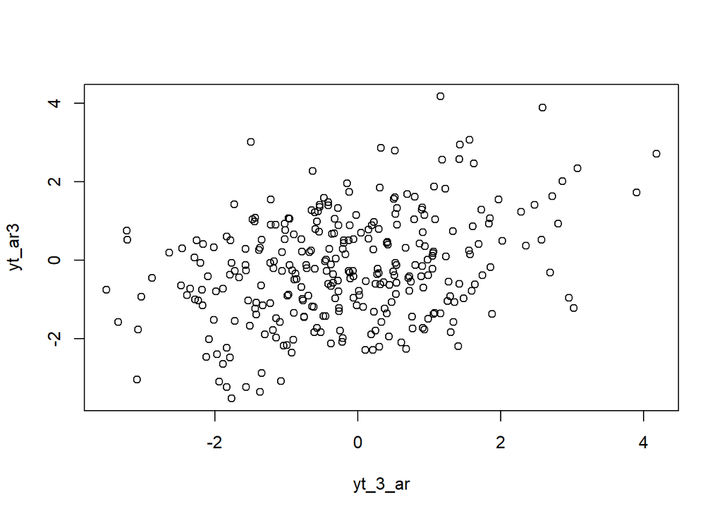

```r
plot(y=yt_ar3,x=yt_3_ar)
```

```r
cor(yt_ar3,yt_3_ar)
```

```
## [1] 0.3265561
```

## Nilai Autokorelasi

### Dari Data Bangkitan

#### WN Manual

```r
acf_manual <- acf(ar2_manual, lag.max = 10, plot = FALSE)
acf_manual$acf
```

```
## , , 1
##
##              [,1]
##  [1,]  1.00000000
##  [2,]  0.62340143
##  [3,]  0.52496196
##  [4,]  0.33782056
##  [5,]  0.29943956
##  [6,]  0.26073461
##  [7,]  0.21389066
##  [8,]  0.18389297
##  [9,]  0.07850616
## [10,]  0.04342730
## [11,] -0.08012096
```

#### WN Arima.sim

```r
acf_asim <- acf(ar2_asim, lag.max = 10, plot = FALSE)
acf_asim$acf
```

```
## , , 1
##
##              [,1]
##  [1,]  1.00000000
##  [2,]  0.60680788
##  [3,]  0.51251093
##  [4,]  0.32140968
##  [5,]  0.29717817
##  [6,]  0.25875009
##  [7,]  0.21092741
##  [8,]  0.18211308
##  [9,]  0.07684567
## [10,]  0.04525311
## [11,] -0.08599730
```

### Secara Teoritis

```r
phi1 <- 0.5
phi2 <- 0.2

# rho0
rho0 <- 1

# rho1 (rumus Yule-Walker)
rho1 <- phi1 / (1 - phi2)

# rho2 (pakai persamaan Yule-Walker)
rho2 <- (phi1 * rho1 + phi2 * rho0)

# lanjutkan untuk lag berikutnya
rho_teori <- numeric(11)  # sampai lag 10
rho_teori[1] <- rho0
rho_teori[2] <- rho1
rho_teori[3] <- rho2

for(k in 3:10){
  rho_teori[k+1] <- phi1 * rho_teori[k] + phi2 * rho_teori[k-1]
}

rho_teori
```

```
##  [1] 1.00000000 0.62500000 0.51250000 0.38125000 0.29312500 0.22281250
##  [7] 0.17003125 0.12957812 0.09879531 0.07531328 0.05741570
```

### Perbandingan dan Kesimpulan

```r
data.frame(
  Lag = 0:10,
  Empiris_Manual = round(acf_manual$acf[1:11], 3),
  Empiris_ArimaSim = round(acf_asim$acf[1:11], 3),
  Teoritis = round(rho_teori, 3)
)
```

```
##    Lag Empiris_Manual Empiris_ArimaSim Teoritis
## 1    0          1.000            1.000    1.000
## 2    1          0.623            0.607    0.625
## 3    2          0.525            0.513    0.512
## 4    3          0.338            0.321    0.381
## 5    4          0.299            0.297    0.293
## 6    5          0.261            0.259    0.223
## 7    6          0.214            0.211    0.170
## 8    7          0.184            0.182    0.130
## 9    8          0.079            0.077    0.099
## 10   9          0.043            0.045    0.075
## 11  10         -0.080           -0.086    0.057
```

Hasil perhitungan autokorelasi menunjukkan bahwa nilai autokorelasi empiris, baik dari data bangkitan manual maupun dengan fungsi arima.sim, relatif konsisten dan mendekati nilai teoritis yang dihitung berdasarkan model AR. Pola autokorelasi terlihat menurun seiring bertambahnya lag, sesuai karakteristik model AR(2) yang secara teoritis memang menghasilkan autokorelasi yang berangsur mengecil namun tetap positif. Perbedaan kecil antara nilai empiris dan teoritis dapat dijelaskan oleh adanya variasi acak dari proses simulasi.

# Kasus 3 - ARMA(2,2)

## Pembangkitan Data

### WN Manual

```r
set.seed(1061)

arma.sim <- function(n, macoef, arcoef){
  manum <- length(macoef)
  arnum <- length(arcoef)
  stopifnot(manum < n & arnum < n)

  wn <- rnorm(n, sd = 0.5)   # white noise
  init <- max(manum, arnum)

  arma <- wn[1:init]         # inisialisasi awal
  for(i in (init+1):n){
    mastart <- i - manum
    maend <- i-1
    arstart <- i - arnum
    arend <- i-1
    arma[i] <- sum(arcoef * arma[arstart:arend]) +
               sum(macoef * wn[mastart:maend]) +
               wn[i]
  }
  return(arma)
}

phi <- c(0.5, 0.2)
theta <- c(0.4, 0.6)
n <- 300

arma_manual <- arma.sim(n, macoef = theta, arcoef = phi)

arma_manual
```

```
##   [1]  0.74279691 -0.61588497  0.11033234 -1.61892693 -1.68338746 -2.22934291
##   [7] -1.15226900 -0.52101736 -0.56372862 -0.37805171 -0.59786322 -0.17362146
##  [13] -0.16181518 -0.99630119 -1.30498384 -1.22092370 -1.06745755 -0.76587384
##  [19] -0.16600624 -0.12457822  1.10207650  0.60120529  1.36107258  1.40887745
##  [25]  1.61414559  2.05615589  1.29836692  1.76557507  0.39382459  0.25176411
##  [31]  0.43497222 -0.20592357 -0.24948770 -0.96496350 -0.66268640 -0.07452572
##  [37]  0.24341600  0.03147629  0.17362932  0.56139582  0.61841505  1.77306159
##  [43]  1.85693054  1.93098875  1.79493599  1.07683626  0.86988805  0.56267594
##  [49]  0.35719352 -0.43621865 -0.20666566  0.05615628 -0.15347595 -0.22248681
##  [55] -0.47463054 -0.71285506 -1.21704972 -1.38033928 -0.67668913 -0.09522296
##  [61] -0.74610144 -0.80527992 -1.65988547 -1.06887306 -1.48240145 -0.67783706
##  [67] -0.19213888  0.48164659  0.88043889 -0.53163010  0.03257859 -0.93249962
##  [73]  0.70831560 -0.42007810  0.85808563  1.32968841  1.52839197  1.68515804
##  [79]  0.13044296  0.08182108 -0.94271515  0.42021002 -0.23949816  0.50131640
##  [85] -0.78900966 -1.04050230 -0.98345610 -2.11471624 -1.67087736 -2.06103315
```

[output cut: 35 more lines]

```r
length(arma_manual)
```

```
## [1] 300
```

### WN Arima.sim

```r
arma_asim <- arima.sim(
  model = list(ar = phi, ma = theta),
  n = n,
  sd = 0.5
)

arma_asim
```

```
## Time Series:
## Start = 1
## End = 300
## Frequency = 1
##   [1]  1.348538085  1.240652245  2.278422453  1.444395570  0.821631507
##   [6]  0.197001176  0.398912342  0.135358887  0.749541145  0.829518996
##  [11]  0.496603255 -0.321731704 -1.949560175 -1.846905175 -2.107112354
##  [16] -1.861674583 -1.840392751 -0.701888262 -0.459637095  0.064112530
##  [21] -0.093919043 -0.816385928 -1.519600633 -1.577993533 -1.105186352
##  [26] -1.067750505 -0.769861766  0.766241479  1.345378011  1.868952892
##  [31]  0.775771441  0.362890454  0.084449568  0.957778457  1.223673807
##  [36]  1.160990875  0.618998751 -0.425994117 -0.772729275 -1.294704622
##  [41] -0.244242225 -0.608105400  1.075370235  1.109869413  1.594424279
##  [46]  1.734290179  1.863992436  2.892964646  2.782762442  3.211156769
##  [51]  2.672177716  2.235298449  2.550087767  2.443075384  2.422852372
```

[output cut: 49 more lines]

## Karakteristik ARMA(2,2)

### Plot Time Series

#### WN Manual

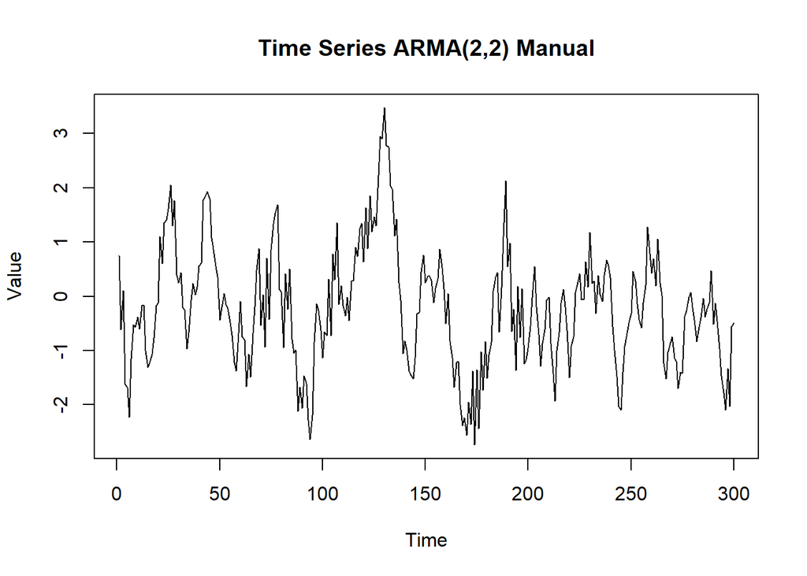

```r
ts.plot(arma_manual, main = "Time Series ARMA(2,2) Manual", ylab = "Value", xlab = "Time")
```

#### WN Arima.sim

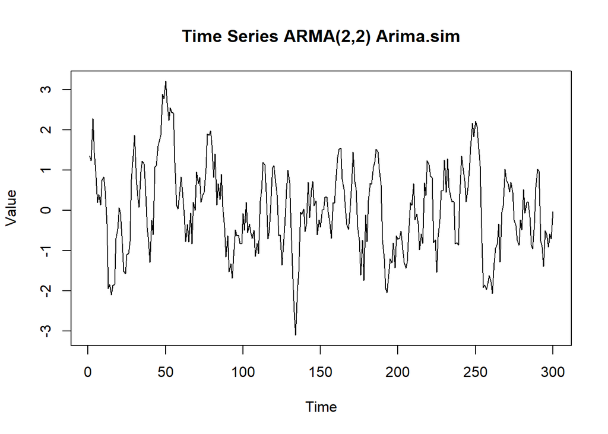

```r
ts.plot(arma_asim, main = "Time Series ARMA(2,2) Arima.sim", ylab = "Value", xlab = "Time")
```

### Plot ACF

#### WN Manual

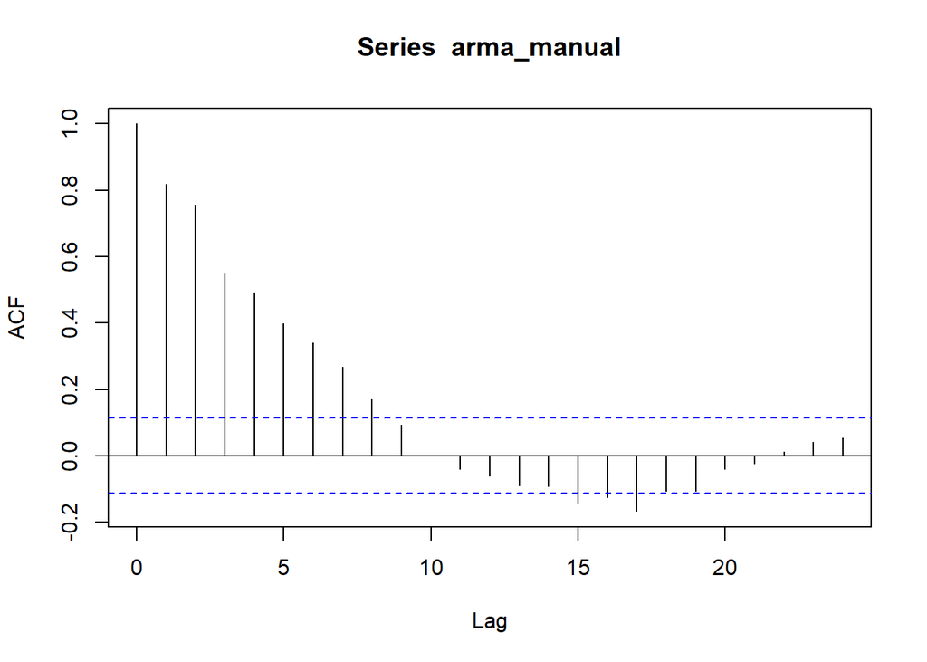

```r
acf(arma_manual)
```

#### WN Arima.sim

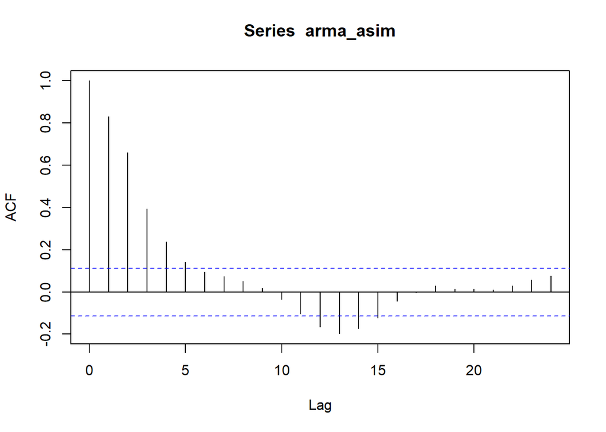

```r
acf(arma_asim)
```

Secara umum, kedua ACF menunjukkan karakteristik ARMA(2,2) yaitu autokorelasi yang menurun secara bertahap. Namun hasil manual cenderung memperlihatkan korelasi positif yang lebih panjang, sedangkan hasil arima.sim lebih cepat memotong dan menurun ke negatif pada lag tinggi.

### Plot PACF

#### WN Manual

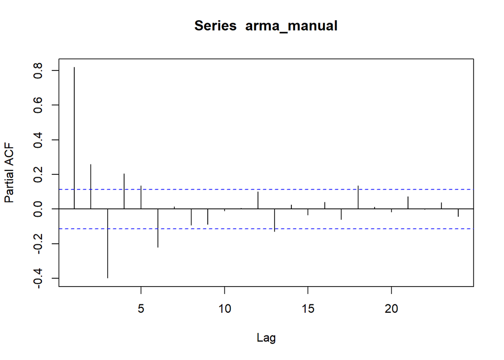

```r
pacf(arma_manual)
```

#### WN Arima.sim

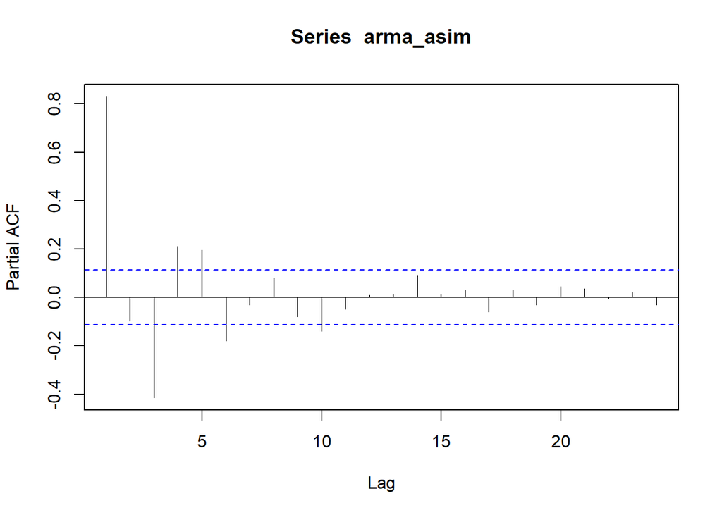

```r
pacf(arma_asim)
```

Berdasarkan kedua plot PACF tersebut, terlihat bahwa model ARMA(2,2) hasil manual dan arima.sim memiliki plot PACF yang *tails off*, sesuai dengan teori

### Plot EACF

#### WN Manual

```r
TSA::eacf(arma_manual)
```

```
## AR/MA
##   0 1 2 3 4 5 6 7 8 9 10 11 12 13
## 0 x x x x x x x x o o o  o  o  o
## 1 x x x x o o x o o o o  o  o  o
## 2 x x x o o o o o x o o  o  o  o
## 3 x x x o o o x o x o o  o  o  o
## 4 x x x o o x x o o o o  o  o  o
## 5 x x o x x x o o o o o  o  o  o
## 6 x x x x x x o x o o x  x  o  o
## 7 x x x x o o x o x o o  x  o  o
```

#### WN Arima.sim

```r
TSA::eacf(arma_asim)
```

```
## AR/MA
##   0 1 2 3 4 5 6 7 8 9 10 11 12 13
## 0 x x x x x o o o o o o  x  x  x
## 1 o x o o o o o o o o o  o  x  o
## 2 x x o o o o o o o o o  o  o  o
## 3 x x o o o o o o o o o  o  o  o
## 4 x x x x o o o o o o o  o  o  o
## 5 x x x x o o o o o o o  o  o  o
## 6 x x x o x x o o o o o  o  o  o
## 7 x o x o o x o o o o o  o  o  o
```

## Scatterplot Antar Lag

### Korelasi antara $Y_t$ dengan $Y_{t-1}$

#### WN Manual

```r
#Yt
yt_ar <- arma_manual[-1]
yt_ar
```

```
##   [1] -0.61588497  0.11033234 -1.61892693 -1.68338746 -2.22934291 -1.15226900
##   [7] -0.52101736 -0.56372862 -0.37805171 -0.59786322 -0.17362146 -0.16181518
##  [13] -0.99630119 -1.30498384 -1.22092370 -1.06745755 -0.76587384 -0.16600624
##  [19] -0.12457822  1.10207650  0.60120529  1.36107258  1.40887745  1.61414559
##  [25]  2.05615589  1.29836692  1.76557507  0.39382459  0.25176411  0.43497222
##  [31] -0.20592357 -0.24948770 -0.96496350 -0.66268640 -0.07452572  0.24341600
##  [37]  0.03147629  0.17362932  0.56139582  0.61841505  1.77306159  1.85693054
##  [43]  1.93098875  1.79493599  1.07683626  0.86988805  0.56267594  0.35719352
##  [49] -0.43621865 -0.20666566  0.05615628 -0.15347595 -0.22248681 -0.47463054
##  [55] -0.71285506 -1.21704972 -1.38033928 -0.67668913 -0.09522296 -0.74610144
##  [61] -0.80527992 -1.65988547 -1.06887306 -1.48240145 -0.67783706 -0.19213888
##  [67]  0.48164659  0.88043889 -0.53163010  0.03257859 -0.93249962  0.70831560
##  [73] -0.42007810  0.85808563  1.32968841  1.52839197  1.68515804  0.13044296
##  [79]  0.08182108 -0.94271515  0.42021002 -0.23949816  0.50131640 -0.78900966
##  [85] -1.04050230 -0.98345610 -2.11471624 -1.67087736 -2.06103315 -1.45982236
```

[output cut: 35 more lines]

```r
#Yt-1
yt_1_ar <- arma_manual[-300]
yt_1_ar
```

```
##   [1]  0.74279691 -0.61588497  0.11033234 -1.61892693 -1.68338746 -2.22934291
##   [7] -1.15226900 -0.52101736 -0.56372862 -0.37805171 -0.59786322 -0.17362146
##  [13] -0.16181518 -0.99630119 -1.30498384 -1.22092370 -1.06745755 -0.76587384
##  [19] -0.16600624 -0.12457822  1.10207650  0.60120529  1.36107258  1.40887745
##  [25]  1.61414559  2.05615589  1.29836692  1.76557507  0.39382459  0.25176411
##  [31]  0.43497222 -0.20592357 -0.24948770 -0.96496350 -0.66268640 -0.07452572
##  [37]  0.24341600  0.03147629  0.17362932  0.56139582  0.61841505  1.77306159
##  [43]  1.85693054  1.93098875  1.79493599  1.07683626  0.86988805  0.56267594
##  [49]  0.35719352 -0.43621865 -0.20666566  0.05615628 -0.15347595 -0.22248681
##  [55] -0.47463054 -0.71285506 -1.21704972 -1.38033928 -0.67668913 -0.09522296
##  [61] -0.74610144 -0.80527992 -1.65988547 -1.06887306 -1.48240145 -0.67783706
##  [67] -0.19213888  0.48164659  0.88043889 -0.53163010  0.03257859 -0.93249962
##  [73]  0.70831560 -0.42007810  0.85808563  1.32968841  1.52839197  1.68515804
##  [79]  0.13044296  0.08182108 -0.94271515  0.42021002 -0.23949816  0.50131640
##  [85] -0.78900966 -1.04050230 -0.98345610 -2.11471624 -1.67087736 -2.06103315
```

[output cut: 35 more lines]

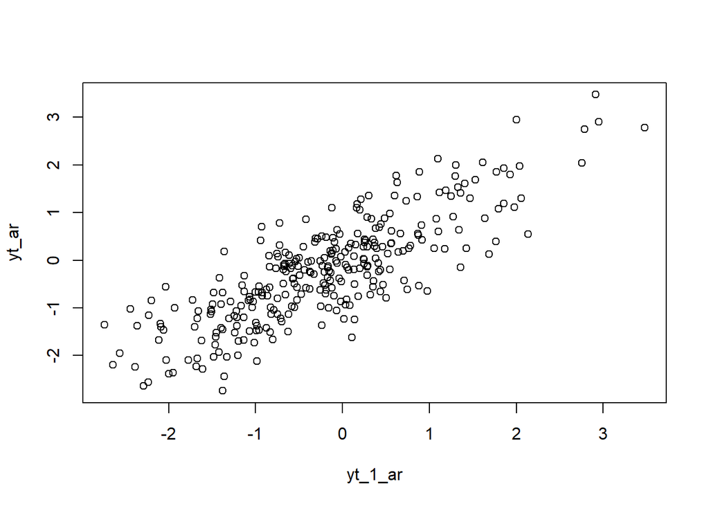

```r
plot(y=yt_ar,x=yt_1_ar)
```

```r
cor(yt_ar,yt_1_ar)
```

```
## [1] 0.8198243
```

#### WN Arima.sim

```r
#Yt
yt_ar <- arma_asim[-1]
yt_ar
```

```
##   [1]  1.240652245  2.278422453  1.444395570  0.821631507  0.197001176
##   [6]  0.398912342  0.135358887  0.749541145  0.829518996  0.496603255
##  [11] -0.321731704 -1.949560175 -1.846905175 -2.107112354 -1.861674583
##  [16] -1.840392751 -0.701888262 -0.459637095  0.064112530 -0.093919043
##  [21] -0.816385928 -1.519600633 -1.577993533 -1.105186352 -1.067750505
##  [26] -0.769861766  0.766241479  1.345378011  1.868952892  0.775771441
##  [31]  0.362890454  0.084449568  0.957778457  1.223673807  1.160990875
##  [36]  0.618998751 -0.425994117 -0.772729275 -1.294704622 -0.244242225
##  [41] -0.608105400  1.075370235  1.109869413  1.594424279  1.734290179
##  [46]  1.863992436  2.892964646  2.782762442  3.211156769  2.672177716
##  [51]  2.235298449  2.550087767  2.443075384  2.422852372  1.190427985
##  [56]  0.119290990  0.036589234  0.461876291  0.834813745  0.457582495
##  [61] -0.136317317 -0.769910389 -0.344451533 -0.781454492 -0.064584304
##  [66] -0.831768356  0.206170001  0.002111439  0.955165166  0.659453087
##  [71]  0.820645448  0.203436254  0.385061503  0.458635934  1.050694894
```

[output cut: 45 more lines]

```r
#Yt-1
yt_1_ar <- arma_asim[-300]
yt_1_ar
```

```
##   [1]  1.348538085  1.240652245  2.278422453  1.444395570  0.821631507
##   [6]  0.197001176  0.398912342  0.135358887  0.749541145  0.829518996
##  [11]  0.496603255 -0.321731704 -1.949560175 -1.846905175 -2.107112354
##  [16] -1.861674583 -1.840392751 -0.701888262 -0.459637095  0.064112530
##  [21] -0.093919043 -0.816385928 -1.519600633 -1.577993533 -1.105186352
##  [26] -1.067750505 -0.769861766  0.766241479  1.345378011  1.868952892
##  [31]  0.775771441  0.362890454  0.084449568  0.957778457  1.223673807
##  [36]  1.160990875  0.618998751 -0.425994117 -0.772729275 -1.294704622
##  [41] -0.244242225 -0.608105400  1.075370235  1.109869413  1.594424279
##  [46]  1.734290179  1.863992436  2.892964646  2.782762442  3.211156769
##  [51]  2.672177716  2.235298449  2.550087767  2.443075384  2.422852372
##  [56]  1.190427985  0.119290990  0.036589234  0.461876291  0.834813745
##  [61]  0.457582495 -0.136317317 -0.769910389 -0.344451533 -0.781454492
##  [66] -0.064584304 -0.831768356  0.206170001  0.002111439  0.955165166
##  [71]  0.659453087  0.820645448  0.203436254  0.385061503  0.458635934
```

[output cut: 45 more lines]

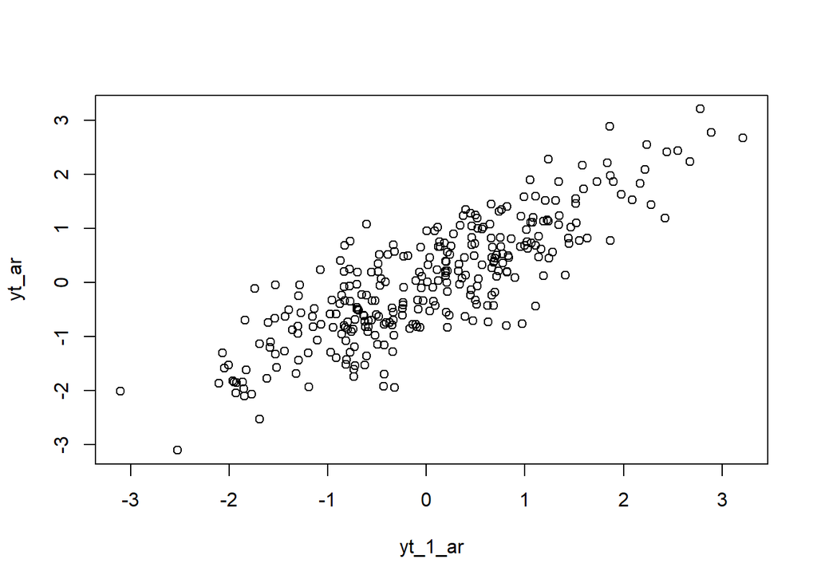

```r
plot(y=yt_ar,x=yt_1_ar)
```

```r
cor(yt_ar,yt_1_ar)
```

```
## [1] 0.8328323
```